# Low microbial biomass within the reproductive tract of late postpartum dairy cows: a study approach

L. Lietaer

This is a notebook for the microbiome analysis data of Lietaer et al. (2020).

When you execute code within the notebook, the results appear beneath the code.

# Statistical analysis preface

Currently the following R packages were loaded

[output not shown]

# Data extraction, transformation and loading

The data was read from the csv file

# Microbial community analyses: taxonomic identification original dataset

## Original dataset - OTU level - all samples and controls

### Create Phyloseq object “physeq” from csv file - original - all samples and controls

```
Compositional = NO2
1] Min. number of reads = 1502] Max. number of reads = 1176813] Total number of reads = 5912024] Average number of reads = 19071.03225806455] Median number of reads = 18627] Sparsity = 0.9539411174080346] Any OTU sum to 1 or less? YES8] Number of singletons = 30979] Percent of OTUs that are singleto…
        (i.e. exactly one read detected across all samples)64.696051806977210] Number of sample variables are: 6SampleAnimalLocationUT_or_VAGSample_or_Controlmerge_factor2
[[1]]
[1] \1] Min. number of reads = 150\

[[2]]
[1] \2] Max. number of reads = 117681\

[[3]]
[1] \3] Total number of reads = 591202\

[[4]]
[1] \4] Average number of reads = 19071.0322580645\

[[5]]
[1] \5] Median number of reads = 1862\

[[6]]
[1] \7] Sparsity = 0.953941117408034\

[[7]]
[1] \6] Any OTU sum to 1 or less? YES\

[[8]]
[1] \8] Number of singletons = 3097\

[[9]]
[1] \9] Percent of OTUs that are singletons \n        (i.e. exactly one read detected across all samples)64.6960518069772\

[[10]]
[1] \10] Number of sample variables are: 6\

[[11]]
[1] \Sample\            \Animal\            \Location\          \UT_or_VAG\
[5] \Sample_or_Control\ \merge_factor\
```

### check rarefaction curves and library size

```
   RT1    RB1    LT1    LB1   VAG1 BLANK1   CTR1 BLANK2    RT2    RB2    LT2    LB2
   290    719    341   1133   5744   7106  58294  22431    485   1073 117681 100921
  VAG2   CTR2    RT3    RB3    LT3    LB3   VAG3   CTR3 BLANK3    RT4    RB4    LT4
  5183  61041    784    412  86456   1862  12929  11063  30100    617    758    289
   LB4   VAG4    RT5    RB5    LT5    LB5   VAG5
  1713  37901   1002    611    150   4161  17952
```

```
   RT1    RB1    LT1    LB1   VAG1 BLANK1   CTR1 BLANK2    RT2    RB2    LT2    LB2
    79     60     47     50    205     90    464    111     26     23    736    711
  VAG2   CTR2    RT3    RB3    LT3    LB3   VAG3   CTR3 BLANK3    RT4    RB4    LT4
   130    733     63     50    633     45    435    450    250     37     41     35
   LB4   VAG4    RT5    RB5    LT5    LB5   VAG5
    33    596     39     37     28    229    369
```

### Visualisation

HEX colors - all samples and controls - family level

```r
phygen.rel.family <- plot_bar(physeqobj25.relab, x ="Sample", fill="Family")
```

```
The sample variables:
Sample
 have been renamed to:
sample_Sample
to avoid conflicts with special phyloseq plot attribute names.
```

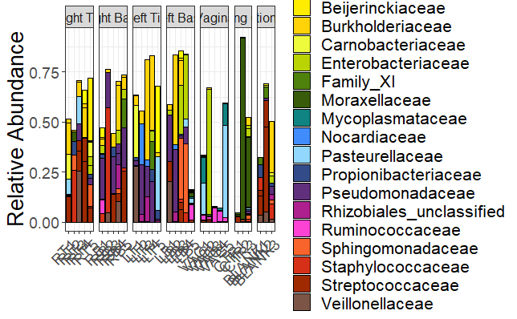

```r
phygen.rel.family +
  facet_grid(~ Location, scales="free_x", space = "free_x") +
  ylab("Relative Abundance")+ xlab("")+
  scale_fill_manual(values= c("#FFFF00", "#FFEC00", "#FFD308", "#EDFB3C", "#BAD303", "#4F820D", "#385C0A", "#0F8482", "#418CFC", "#92D8FE", "#334C89", "#61307D", "#AD208E", "#FC43D3", "#F8642C", "#D63118", "#9F2A00", "#7C5547"))+
  theme_bw()+
  theme(axis.text=element_text(size=14), axis.title=element_text(size=20),
        title=element_text(size=20), legend.text=element_text(size=16),
        axis.text.x = element_text(angle = 45, hjust = 1),
        strip.text = element_text(size = 12))
```

## Original dataset - OTU level - only DNA extraction blank controls

### Create Phyloseq object “physeqblank” from csv file - original - only DNA extraction blank controls

```r
summarize_phyloseq(physeqblank)
```

```
Compositional = NO2
1] Min. number of reads = 71062] Max. number of reads = 301003] Total number of reads = 596374] Average number of reads = 198795] Median number of reads = 224317] Sparsity = 0.9685955017060096] Any OTU sum to 1 or less? YES8] Number of singletons = 46699] Percent of OTUs that are singletons
        (i.e. exactly one read detected across all samples)6.4340923334029710] Number of sample variables are: 6SampleAnimalLocationUT_or_VAGSample_or_Controlmerge_factor2
```

```
[[1]]
[1] "1] Min. number of reads = 7106"

[[2]]
[1] "2] Max. number of reads = 30100"

[[3]]
[1] "3] Total number of reads = 59637"

[[4]]
[1] "4] Average number of reads = 19879"

[[5]]
[1] "5] Median number of reads = 22431"

[[6]]
[1] "7] Sparsity = 0.968595501706009"

[[7]]
[1] "6] Any OTU sum to 1 or less? YES"

[[8]]
[1] "8] Number of singletons = 4669"

[[9]]
[1] "9] Percent of OTUs that are singletons \n        (i.e. exactly one read detected across all samples)6.43409233340297"

[[10]]
[1] "10] Number of sample variables are: 6"

[[11]]
[1] "Sample"            "Animal"            "Location"          "UT_or_VAG"
[5] "Sample_or_Control" "merge_factor"
```

### Visualisation

viridis colors - only DNA extraction blank controls - genus level and family level

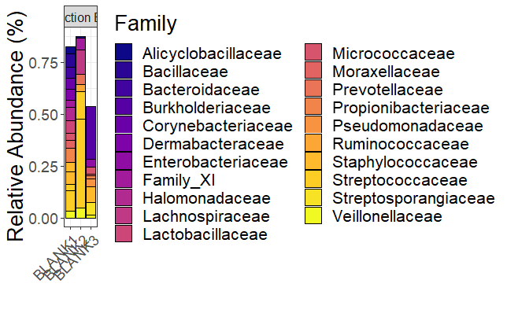

## Original dataset - OTU level - only vaginal samples

### Create Phyloseq object “physeqvag” from csv file - original - only vaginal samples

```r
# Create phyloseq object from csv file
# Taxonomy table
tax_df <-otu_data %>% dplyr::select(OTU:genus)
rownames(tax_df) <- tax_df$OTU
```

```
Setting row names on a tibble is deprecated.
```

```r
# Create OTU table with all samples
otu_df <- otu_data %>% dplyr::select(RT1:VAG5)
vagina_df <- otu_df %>% dplyr::select(VAG1, VAG2, VAG3, VAG4, VAG5)
# Name the rows with the names of the OTUs
rownames(vagina_df) <- tax_df$OTU
```

```
Setting row names on a tibble is deprecated.
```

```r
tax_df <- tax_df %>% dplyr::select(-c(OTU,Size))
physeqvag <- phyloseq(otu_table(vagina_df, taxa_are_rows = TRUE),
                   tax_table(as.matrix(tax_df)))
colnames(tax_table(physeqvag)) <- c("Kingdom", "Phylum", "Class", "Order", "Family", "Genus")
rownames(metadata) <- metadata$Sample # make sure rownames are matching with physeq
sample_data(physeqvag) <- sample_data(metadata) # add metadata
summarize_phyloseq(physeqvag)
```

```
Compositional = NO2
1] Min. number of reads = 51832] Max. number of reads = 379013] Total number of reads = 797094] Average number of reads = 15941.85] Median number of reads = 129297] Sparsity = 0.927512011698356] Any OTU sum to 1 or less? YES8] Number of singletons = 39769] Percent of OTUs that are singletons
        (i.e. exactly one read detected across all samples)10.256945895132710] Number of sample variables are: 6SampleAnimalLocationUT_or_VAGSample_or_Controlmerge_factor2
```

```
[[1]]
[1] "1] Min. number of reads = 5183"

[[2]]
[1] "2] Max. number of reads = 37901"

[[3]]
[1] "3] Total number of reads = 79709"

[[4]]
[1] "4] Average number of reads = 15941.8"

[[5]]
[1] "5] Median number of reads = 12929"

[[6]]
[1] "7] Sparsity = 0.92751201169835"

[[7]]
[1] "6] Any OTU sum to 1 or less? YES"

[[8]]
[1] "8] Number of singletons = 3976"

[[9]]
[1] "9] Percent of OTUs that are singletons \n        (i.e. exactly one read detected across all samples)10.2569458951327"

[[10]]
[1] "10] Number of sample variables are: 6"

[[11]]
[1] "Sample"            "Animal"            "Location"          "UT_or_VAG"
[5] "Sample_or_Control" "merge_factor"
```

### Visualisation

only vaginal samples - genus level (viridis colors) and family level (HEX colors)

```r
### Select 25 top otus based on relative abunance
# Relative abundance
relabsphyseqvag <- transform_sample_counts(physeqvag , function(x) x/sum(x))
# Select 25 top otus based on relative abunance
TopNOTUs.relabvag <- names(sort(taxa_sums(relabsphyseqvag), TRUE)[1:25])
physeqobj25.relabvag  <- prune_taxa(TopNOTUs.relabvag, relabsphyseqvag)
# Genus level barplot
phyplot.relvag.genus <- plot_bar(physeqobj25.relabvag, x ="Sample", fill="Genus")
```

```
The sample variables:
Sample
 have been renamed to:
sample_Sample
to avoid conflicts with special phyloseq plot attribute names.
```

[figure not shown]

```r
phyplot.relvag.genus +
  facet_grid(~ Location, scales="free_x", space = "free_x") +
  ylab("Relative Abundance (%)")+ xlab("")+
  scale_fill_viridis(discrete=TRUE, option="plasma")+
  theme_bw()+
  theme(axis.text=element_text(size=14), axis.title=element_text(size=20),
        title=element_text(size=20), legend.text=element_text(size=16),
        axis.text.x = element_text(angle = 45, hjust = 1),
        strip.text = element_text(size = 12))
```

```r
# family level barplot
phyplot.relvag.family <- plot_bar(physeqobj25.relabvag, x ="Sample", fill="Family")
```

```
The sample variables:
Sample
 have been renamed to:
sample_Sample
to avoid conflicts with special phyloseq plot attribute names.
```

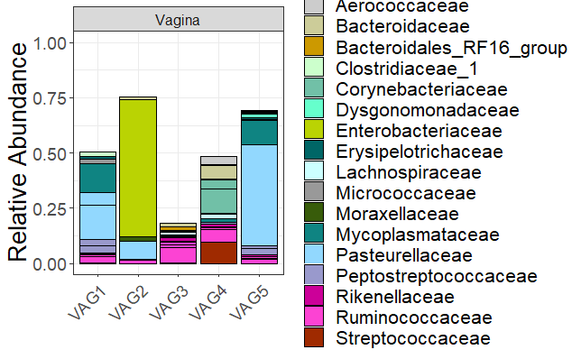

```r
phyplot.relvag.family +
  facet_grid(~ Location, scales="free_x", space = "free_x") +
  scale_y_continuous(breaks=seq(0,1,0.25), limits=c(0,1))+
  ylab("Relative Abundance")+ xlab("")+
  scale_fill_manual(values= c("#CCCCCC", "#CCCC99", "#CC9900", "#CCFFCC", "#71C0A7", "#66FFCC", "#BAD303", "#006666", "#CCFFFF", "#999999", "#385C0A", "#0F8482", "#92D8FE", "#9999CC", "#CC0099", "#FC43D3", "#9F2A00"))+
  theme_bw()+
  theme(axis.text=element_text(size=14), axis.title=element_text(size=20),
        title=element_text(size=20), legend.text=element_text(size=16),
        axis.text.x = element_text(angle = 45, hjust = 1),
        strip.text = element_text(size = 12))
```

## Original dataset - OTU level - only uterine samples

### Create Phyloseq object “physequt” from csv file - original - only uterine samples

```r
# metadata
metadata_uterus <- metadata[c(1:4, 9:12, 15:18, 22:25, 27:30),]

# Create phyloseq object from csv file
# Taxonomy table
tax_df <-otu_data %>% dplyr::select(OTU:genus)
rownames(tax_df) <- tax_df$OTU

# Create OTU table "uterus_df" with only uterine samples
otu_df <- otu_data %>% dplyr::select(RT1:VAG5)
uterus_df <- otu_df %>% dplyr::select(RT1,RT2,RT3,RT4,RT5,RB1,RB2,RB3,RB4,RB5,LT1,LT2,LT3,LT4,LT5,LB1,LB2,LB3,LB4,LB5)

# Name the rows with the names of the OTUs
rownames(uterus_df) <- tax_df$OTU

tax_df <- tax_df %>% dplyr::select(-c(OTU,Size))

physequterus <- phyloseq(otu_table(uterus_df, taxa_are_rows = TRUE),
                   tax_table(as.matrix(tax_df)))

colnames(tax_table(physequterus)) <- c("Kingdom", "Phylum", "Class", "Order", "Family", "Genus")
rownames(metadata) <- metadata$Sample # make sure rownames are matching with physeq
sample_data(physequterus) <- sample_data(metadata) # add metadata

summarize_phyloseq(physequterus)
```

[output not shown]

```r
# Extract abundance matrix from the phyloseq object
otu_uterus = as(otu_table(physequterus), "matrix")
# transpose if necessary
if(taxa_are_rows(physequterus)){otu_uterus <- t(otu_uterus)}
# Coerce to data.frame
OTUdf_uterus = as.data.frame(otu_uterus)
```

### Visualisation

viridis colors - only uterine samples - genus level (viridis colors) and family level (HEX colors)

```r
### Select 25 top otus based on relative abundance
#Relative abundance
relabphysequterus <- transform_sample_counts(physequterus , function(x) x/sum(x))
### Select 25 top otus based on relative abunance
TopNOTUs.relabuterus <- names(sort(taxa_sums(relabphysequterus), TRUE)[1:25])
physeqobj25.relabuterus  <- prune_taxa(TopNOTUs.relabuterus, relabphysequterus)
# genus level barplot
phyplot.relut.genus <- plot_bar(physeqobj25.relabuterus, x ="Sample", fill="Genus")
```

```
The sample variables:
Sample
 have been renamed to:
sample_Sample
to avoid conflicts with special phyloseq plot attribute names.
```

[figure not shown]

```r
phyplot.relut.genus +
  facet_grid(~ Location, scales="free_x", space = "free_x") +
  ylab("Relative Abundance (%)")+ xlab("")+
  scale_fill_viridis(discrete=TRUE, option="plasma")+
  theme_bw()+
  theme(axis.text=element_text(size=14), axis.title=element_text(size=20),
        title=element_text(size=20), legend.text=element_text(size=16),
        axis.text.x = element_text(angle = 45, hjust = 1),
        strip.text = element_text(size = 12))
```

```r
# family level barplot
phyplot.relut.family <- plot_bar(physeqobj25.relabuterus, x ="Sample", fill="Family")
```

```
The sample variables:
Sample
 have been renamed to:
sample_Sample
to avoid conflicts with special phyloseq plot attribute names.
```

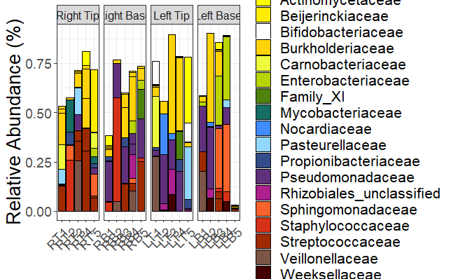

```r
phyplot.relut.family +
  facet_grid(~ Location, scales="free_x", space = "free_x") +
  ylab("Relative Abundance (%)")+ xlab("")+
  scale_fill_manual(values= c("#FFFF00", "#FFEC00", "#FFFFFF", "#FFD308", "#EDFB3C", "#BAD303", "#4F820D", "#166D66", "#418CFC", "#92D8FE", "#334C89", "#61307D", "#AD208E", "#F8642C", "#D63118", "#9F2A00", "#7C5547", "#440000"))+
  theme_bw()+
  theme(axis.text=element_text(size=14), axis.title=element_text(size=20),
        title=element_text(size=20), legend.text=element_text(size=16),
        axis.text.x = element_text(angle = 45, hjust = 1),
        strip.text = element_text(size = 12))
```

```r
NA
```

## Original dataset - pooled by Phylum level - all samples and controls

### Create Phyloseq object “physeq_phylum_scale” - original - pooled by phylum level - all samples and controls

```r
# start from Phyloseq object physeq -> Pool at phylum level to make physeq_scale
physeq_phylum_scale = tax_glom(physeq, "Phylum")

# Calculate relative abundances
relabphyseq_phylum_scale <- transform_sample_counts(physeq_phylum_scale, function(x) 100*x/sum(x))

# Select top 5 phyla, and all others combined in "other"
TopNPhyla.relabphyseq_phylum_scale <- names(sort(taxa_sums(relabphyseq_phylum_scale), TRUE)[1:5])
tax_table(relabphyseq_phylum_scale)[!taxa_names(relabphyseq_phylum_scale) %in% TopNPhyla.relabphyseq_phylum_scale, "Phylum"] <- "Other"

# psmelt into dataframe
df_relabphyseq_phylum_scale_pruned <- psmelt(relabphyseq_phylum_scale)

sum_table_phyla <- df_relabphyseq_phylum_scale_pruned %>% group_by(Phylum) %>% summarize(sum_abund = sum(Abundance))

# sort phyla in order of abundance, put "other" last
names_sorted_phyla <- as.character(sum_table_phyla$Phylum)[order(sum_table_phyla$sum_abund, decreasing = TRUE)]
names_sorted_phyla <- c(names_sorted_phyla[names_sorted_phyla != "Other"],
                         names_sorted_phyla[names_sorted_phyla == "Other"])

df_relabphyseq_phylum_scale_pruned$Phylum <- factor(as.character(df_relabphyseq_phylum_scale_pruned$Phylum),
                                       levels = names_sorted_phyla)

# Finally we merge the Phyla present in "Others"
df_relabphyseq_phylum_scale_pruned_remerged <- df_relabphyseq_phylum_scale_pruned %>%
  group_by(Phylum, Sample) %>% summarize(sum_abund = sum(Abundance))

# Add metadata AGAIN
df_relabphyseq_phylum_scale_pruned_remerged <- left_join(df_relabphyseq_phylum_scale_pruned_remerged,
                                             metadata[-6],
                                                by = c("Sample" = "Sample")
                                             ) %>% distinct()
```

### Visualisation

all samples and controls - phylum level

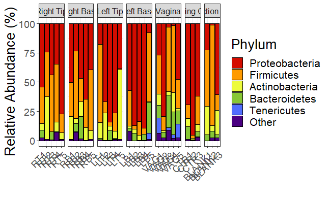

```r
# Generate a plot with the relative abundances pooled by phylum - facet by Location
phyplot.phylum <- ggplot(aes(Sample, y = sum_abund,
                        fill = Phylum, color = Phylum), data = df_relabphyseq_scale_pruned_remerged)+
  geom_bar(stat="identity", alpha = 1)+
  scale_color_manual(values = rep("black", 26))+
  facet_grid(~ Location, scales="free_x", space = "free_x") +
  ylab("Relative Abundance (%)")+ xlab("")+
  scale_fill_manual(values= c("#D40C00", "#FF9A00", "#EDFB3C", "#87C735", "#526EFF", "#4B0082"))+
  theme_bw()+
  theme(axis.text=element_text(size=14), axis.title=element_text(size=20),
        title=element_text(size=20), legend.text=element_text(size=16),
        axis.text.x = element_text(angle = 45, hjust = 1),
        strip.text = element_text(size = 12))
print(phyplot.phylum)
```

## Original dataset - pooled by Family level - all samples and controls

### Create Phyloseq object “physeq_family_scale” - original - pooled by family level - all samples and controls

```r
# Pool at family level
physeq_family_scale = tax_glom(physeq, "Family")
# Calculate relative abundances
relabphyseq_family_scale <- transform_sample_counts(physeq_family_scale, function(x) 100*x/sum(x))
# Select top 5 families
TopNFamilies.relabphyseq_family_scale <- names(sort(taxa_sums(relabphyseq_family_scale), TRUE)[1:5])
tax_table(relabphyseq_family_scale)[!taxa_names(relabphyseq_family_scale) %in% TopNFamilies.relabphyseq_family_scale, "Family"] <- "Other"
# psmelt into dataframe
df_relabphyseq_family_scale_pruned <- psmelt(relabphyseq_family_scale)
```

```
The sample variables:
Sample
 have been renamed to:
sample_Sample
to avoid conflicts with special phyloseq plot attribute names.
```

```r
sum_table_families <- df_relabphyseq_family_scale_pruned %>% group_by(Family) %>% summarize(sum_abund = sum(Abundance))
# sort families in order of abundance, put "other" last
names_sorted_families <- as.character(sum_table_families$Family)[order(sum_table_families$sum_abund,
                                                                  decreasing = TRUE)]
names_sorted_families <- c(names_sorted_families[names_sorted_families != "Other"],
                         names_sorted_families[names_sorted_families == "Other"])
df_relabphyseq_family_scale_pruned$Family <- factor(as.character(df_relabphyseq_family_scale_pruned$Family),
                                       levels = names_sorted_families)
# Finally we merge the Genera present in "Others"
df_relabphyseq_family_scale_pruned_remerged <- df_relabphyseq_family_scale_pruned %>%
  group_by(Family, Sample) %>% summarize(sum_abund = sum(Abundance))
# Add metadata AGAIN
df_relabphyseq_family_scale_pruned_remerged <- left_join(df_relabphyseq_family_scale_pruned_remerged,
                                             metadata[-6],
                                                by = c("Sample" = "Sample")
                                             ) %>% distinct()
```

### Visualisation

all samples and controls - family level

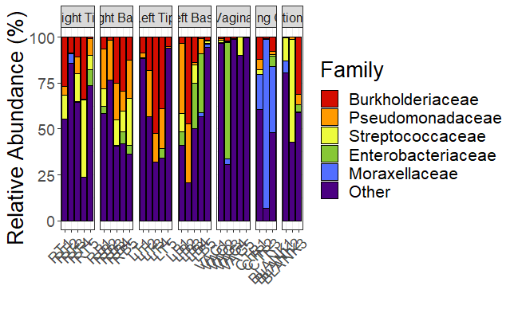

```r
# Generate a plot with the relative abundances pooled by family - facet by Location
phyplot.family <- ggplot(aes(Sample, y = sum_abund,
                        fill = Family, color = Family), data = df_relabphyseq_family_scale_pruned_remerged)+
  geom_bar(stat="identity", alpha = 1)+
  scale_color_manual(values = rep("black", 26))+
  facet_grid(~ Location, scales="free_x", space = "free_x") +
  ylab("Relative Abundance (%)")+ xlab("")+
  scale_fill_manual(values= c("#D40C00", "#FF9A00", "#EDFB3C", "#87C735", "#526EFF", "#4B0082"))+
  theme_bw()+
  theme(axis.text=element_text(size=14), axis.title=element_text(size=20),
        title=element_text(size=20), legend.text=element_text(size=16),
        axis.text.x = element_text(angle = 45, hjust = 1),
        strip.text = element_text(size = 12))
print(phyplot.family)
```

## Original dataset - pooled by Family level - only vaginal samples

### Create Phyloseq object “physeqvag_family_scale” - original - pooled by family level - only vaginal samples

```r
# Pool at family level
physeqvag_family_scale = tax_glom(physeqvag, "Family")
# Calculate relative abundances
relabphyseqvag_family_scale <- transform_sample_counts(physeqvag_family_scale, function(x) 100*x/sum(x))
# Select top 5 families
TopNFamilies.relabphyseqvag_family_scale <- names(sort(taxa_sums(relabphyseqvag_family_scale), TRUE)[1:5])
tax_table(relabphyseqvag_family_scale)[!taxa_names(relabphyseqvag_family_scale) %in% TopNFamilies.relabphyseqvag_family_scale, "Family"] <- "Other"
# psmelt into dataframe
df_relabphyseqvag_family_scale_pruned <- psmelt(relabphyseqvag_family_scale)
```

```
The sample variables:
Sample
 have been renamed to:
sample_Sample
to avoid conflicts with special phyloseq plot attribute names.
```

```r
sum_table_families <- df_relabphyseqvag_family_scale_pruned %>% group_by(Family) %>% summarize(sum_abund = sum(Abundance))
# sort families in order of abundance, put "other" last
names_sorted_families <- as.character(sum_table_families$Family)[order(sum_table_families$sum_abund,
                                                                  decreasing = TRUE)]
names_sorted_families <- c(names_sorted_families[names_sorted_families != "Other"],
                         names_sorted_families[names_sorted_families == "Other"])
df_relabphyseqvag_family_scale_pruned$Family <- factor(as.character(df_relabphyseqvag_family_scale_pruned$Family),
                                       levels = names_sorted_families)
# Finally we merge the families present in "Others"
df_relabphyseqvag_family_scale_pruned_remerged <- df_relabphyseqvag_family_scale_pruned %>%
  group_by(Family, Sample) %>% summarize(sum_abund = sum(Abundance))
# Add metadata AGAIN
df_relabphyseqvag_family_scale_pruned_remerged <- left_join(df_relabphyseqvag_family_scale_pruned_remerged,
                                             metadata[-6],
                                                by = c("Sample" = "Sample")
                                             ) %>% distinct()
```

### Visualisation

only vaginal samples - family level

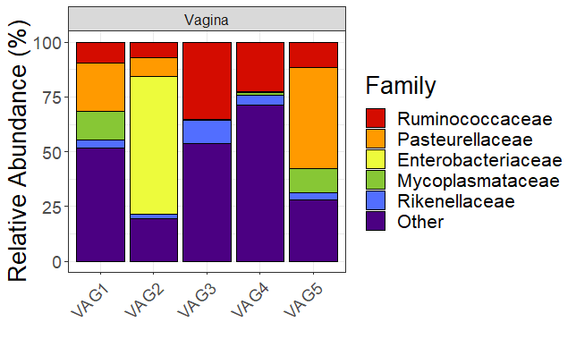

```r
# Generate a plot with the relative abundances pooled by family - facet by Location
phyplot.family.vag <- ggplot(aes(Sample, y = sum_abund,
                        fill = Family, color = Family), data = df_relabphyseqvag_family_scale_pruned_remerged)+
  geom_bar(stat="identity", alpha = 1)+
  scale_color_manual(values = rep("black", 26))+
  facet_grid(~ Location, scales="free_x", space = "free_x") +
  ylab("Relative Abundance (%)")+ xlab("")+
  scale_fill_manual(values= c("#D40C00", "#FF9A00", "#EDFB3C", "#87C735", "#526EFF", "#4B0082"))+
  theme_bw()+
  theme(axis.text=element_text(size=14), axis.title=element_text(size=20),
        title=element_text(size=20), legend.text=element_text(size=16),
        axis.text.x = element_text(angle = 45, hjust = 1),
        strip.text = element_text(size = 12))
print(phyplot.family.vag)
```

## Original dataset - pooled by Family level - only uterine samples

### Create Phyloseq object “physequterus_family_scale” - original - pooled by family level - only uterine samples

```r
# Pool at family level
physequterus_family_scale = tax_glom(physequterus, "Family")
# Calculate relative abundances
relabphysequterus_family_scale <- transform_sample_counts(physequterus_family_scale, function(x) 100*x/sum(x))
# Select top 5 families
TopNFamilies.relabphysequterus_family_scale <- names(sort(taxa_sums(relabphysequterus_family_scale), TRUE)[1:5])
tax_table(relabphysequterus_family_scale)[!taxa_names(relabphysequterus_family_scale) %in% TopNFamilies.relabphysequterus_family_scale, "Family"] <- "Other"
# psmelt into dataframe
df_relabphysequterus_family_scale_pruned <- psmelt(relabphysequterus_family_scale)
```

```
The sample variables:
Sample
 have been renamed to:
sample_Sample
to avoid conflicts with special phyloseq plot attribute names.
```

```r
sum_table_families <- df_relabphysequterus_family_scale_pruned %>% group_by(Family) %>% summarize(sum_abund = sum(Abundance))
# sort families in order of abundance, put "other" last
names_sorted_families <- as.character(sum_table_families$Family)[order(sum_table_families$sum_abund,
                                                                  decreasing = TRUE)]
names_sorted_families <- c(names_sorted_families[names_sorted_families != "Other"],
                         names_sorted_families[names_sorted_families == "Other"])
df_relabphysequterus_family_scale_pruned$Family <- factor(as.character(df_relabphysequterus_family_scale_pruned$Family),
                                       levels = names_sorted_families)
# Finally we merge the families present in "Others"
df_relabphysequterus_family_scale_pruned_remerged <- df_relabphysequterus_family_scale_pruned %>%
  group_by(Family, Sample) %>% summarize(sum_abund = sum(Abundance))
# Add metadata AGAIN
df_relabphysequterus_family_scale_pruned_remerged <- left_join(df_relabphysequterus_family_scale_pruned_remerged,
                                             metadata[-6],
                                                by = c("Sample" = "Sample")
                                             ) %>% distinct()
```

### Visualisation

only uterine samples - family level

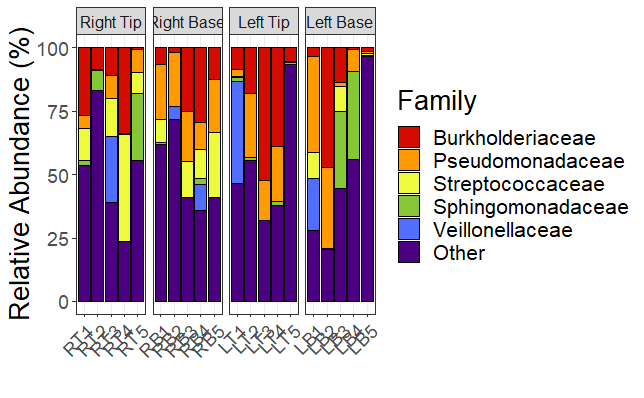

```r
# Generate a plot with the relative abundances pooled by family - facet by Location
phyplot.family.uterus <- ggplot(aes(Sample, y = sum_abund,
                        fill = Family, color = Family), data = df_relabphysequterus_family_scale_pruned_remerged)+
  geom_bar(stat="identity", alpha = 1)+
  scale_color_manual(values = rep("black", 26))+
  facet_grid(~ Location, scales="free_x", space = "free_x") +
  ylab("Relative Abundance (%)")+ xlab("")+
  scale_fill_manual(values= c("#D40C00", "#FF9A00", "#EDFB3C", "#87C735", "#526EFF", "#4B0082"))+
  theme_bw()+
  theme(axis.text=element_text(size=14), axis.title=element_text(size=20),
        title=element_text(size=20), legend.text=element_text(size=16),
        axis.text.x = element_text(angle = 45, hjust = 1),
        strip.text = element_text(size = 12))
print(phyplot.family.uterus)
```

# Microbial community analyses: alpha and beta diversities

## Alpha diversity

### Original dataset - uterine samples

```r
alpha_uterus <- estimate_richness(physequterus, measures = c("Shannon", "InvSimpson"))
alpha_uterus
```

```
     Shannon InvSimpson
RT1 3.320240  13.887054
RT2 2.312573   7.375443
RT3 2.566760   8.208547
RT4 2.164008   6.067047
RT5 2.280167   6.400638
RB1 2.741815  10.451891
RB2 1.611827   3.115380
RB3 2.591644   8.708393
RB4 2.653566   9.859359
RB5 2.270372   6.786051
LT1 2.266606   5.610122
LT2 2.528326   7.731084
LT3 1.819211   3.370553
LT4 2.064872   4.766364
LT5 2.169871   5.011136
LB1 2.451619   7.841573
LB2 1.703573   3.232089
LB3 2.082463   5.434153
LB4 1.823164   4.222654
LB5 4.600098  62.291719
```

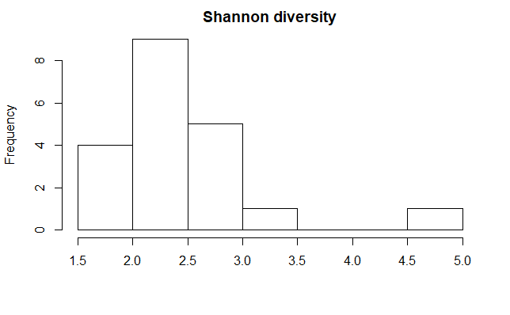

```r
hist(alpha_uterus$Shannon, main="Shannon diversity", xlab="", breaks=10)
```

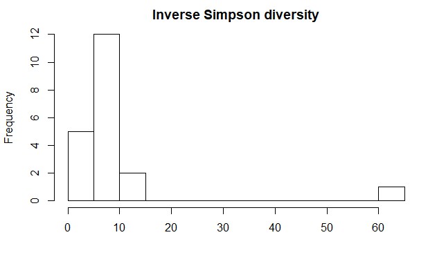

```r
hist(alpha_uterus$InvSimpson, main="Inverse Simpson diversity", xlab="", breaks=10)
```

```r
shapiro.test(alpha_uterus$Shannon)
```

```
    Shapiro-Wilk normality test

data:  alpha_uterus$Shannon
W = 0.80603, p-value = 0.001064
```

```r
shapiro.test(alpha_uterus$InvSimpson)
```

```
    Shapiro-Wilk normality test

data:  alpha_uterus$InvSimpson
W = 0.42175, p-value = 6.708e-08
```

```r
kruskallocation_alpha_uterus <- t(sapply(alpha_uterus, function(x) unlist(kruskal.test(x~sample_data(physequterus)$Location)[c("estimate","p.value","statistic","conf.int")])))
kruskallocation_alpha_uterus
```

```
             p.value statistic.Kruskal-Wallis chi-squared
Shannon    0.4515105                             2.634286
InvSimpson 0.3278713                             3.445714
```

```r
dunn.test(alpha_uterus$Shannon, sample_data(physequterus)$Location, method="bonferroni")
```

```
  Kruskal-Wallis rank sum test

data: x and group
Kruskal-Wallis chi-squared = 2.6343, df = 3, p-value = 0.45

                           Comparison of x by group
                                 (Bonferroni)
Col Mean-|
Row Mean |   Left Bas   Left Tip   Right Ba
---------+---------------------------------
Left Tip |   0.320713
         |     1.0000
Right Ba |  -0.908688  -1.229401
         |     1.0000     0.6568
Right Ti |  -1.015592  -1.336306  -0.106904
         |     0.9295     0.5443     1.0000

alpha = 0.05
Reject Ho if p <= alpha/2
```

```r
dunn.test(alpha_uterus$InvSimpson, sample_data(physequterus)$Location, method="bonferroni")
```

```
  Kruskal-Wallis rank sum test

data: x and group
Kruskal-Wallis chi-squared = 3.4457, df = 3, p-value = 0.33

                           Comparison of x by group
                                 (Bonferroni)
Col Mean-|
Row Mean |   Left Bas   Left Tip   Right Ba
---------+---------------------------------
Left Tip |   0.641426
         |     1.0000
Right Ba |  -0.855235  -1.496662
         |     1.0000     0.4034
Right Ti |  -0.962140  -1.603567  -0.106904
         |     1.0000     0.3264     1.0000

alpha = 0.05
Reject Ho if p <= alpha/2
```

```r
location <- c(rep(c("RT","RB","LT","LB"), each = 5))
alpha_uterus <- cbind(alpha_uterus, location)
alpha_uterus
```

```
     Shannon InvSimpson location
RT1 3.320240  13.887054       RT
RT2 2.312573   7.375443       RT
RT3 2.566760   8.208547       RT
RT4 2.164008   6.067047       RT
RT5 2.280167   6.400638       RT
RB1 2.741815  10.451891       RB
RB2 1.611827   3.115380       RB
RB3 2.591644   8.708393       RB
RB4 2.653566   9.859359       RB
RB5 2.270372   6.786051       RB
LT1 2.266606   5.610122       LT
LT2 2.528326   7.731084       LT
LT3 1.819211   3.370553       LT
LT4 2.064872   4.766364       LT
LT5 2.169871   5.011136       LT
LB1 2.451619   7.841573       LB
LB2 1.703573   3.232089       LB
LB3 2.082463   5.434153       LB
LB4 1.823164   4.222654       LB
LB5 4.600098  62.291719       LB
```

#### Visualisation

Plot alpha diversity original dataset, uterine samples

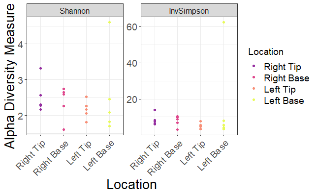

```r
# plot alpha diversity original dataset, uterine samples
plot_alpha_uterus <- plot_richness(physequterus, x="Location", measures=c("Shannon", "InvSimpson"), color="Location")
plot_alpha_uterus +  theme_bw() +
  scale_color_manual(values= c("#952EA0","#DF488D", "#F89078", "#e8fa5bff"))+
  theme(axis.text=element_text(size=14), axis.title=element_text(size=20),
        title=element_text(size=14), legend.text=element_text(size=14),
        axis.text.x = element_text(angle = 45, hjust = 1),
        strip.text = element_text(size = 12))
```

Plot alpha diversity original dataset, uterine samples, with P-values

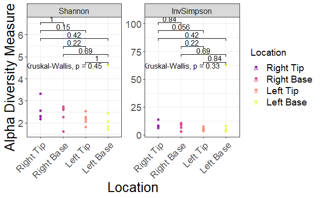

```r
my_comparisons_alpha_location <- list( c("Left Tip", "Left Base"), c("Right Base", "Left Base"), c("Right Base", "Left Tip"), c("Right Tip", "Left Base"), c("Right Tip", "Left Tip"), c("Right Tip", "Right Base") )
plot_alpha_uterus_P <- plot_richness(physequterus, x="Location", measures=c("Shannon", "InvSimpson"), color="Location") +
  theme_bw() +
  scale_color_manual(values= c("#952EA0","#DF488D", "#F89078", "#e8fa5bff"))+
  theme(axis.text=element_text(size=14), axis.title=element_text(size=20),
        title=element_text(size=14), legend.text=element_text(size=14),
        axis.text.x = element_text(angle = 45, hjust = 1),
        strip.text = element_text(size = 12)) +
  stat_compare_means(comparisons = my_comparisons_alpha_location)+
  stat_compare_means()
print(plot_alpha_uterus_P)
```

## Beta diversity

### Original dataset - uterine samples

```r
permutest(disp.location, pairwise=TRUE, permutations=1000)
```

```
Permutation test for homogeneity of multivariate dispersions
Permutation: free
Number of permutations: 1000

Response: Distances
          Df   Sum Sq   Mean Sq      F N.Perm Pr(>F)
Groups     3 0.006237 0.0020791 0.2469   1000 0.8492
Residuals 16 0.134711 0.0084195

Pairwise comparisons:
(Observed p-value below diagonal, permuted p-value above diagonal)
           Right Tip Right Base Left Tip Left Base
Right Tip               0.72028  0.86913    0.7912
Right Base   0.70482             0.35265    0.3876
Left Tip     0.87953    0.36004             0.8222
Left Base    0.80170    0.38655  0.83212
```

#### Visualisation

Plot beta diversity original dataset, uterine samples

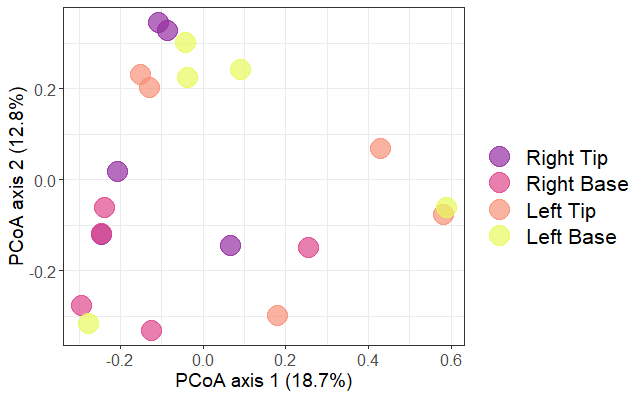

### Original dataset - uterine samples versus vaginal samples

```r
metadata_utvag <- metadata[c(1:5, 9:13, 15:19, 22:31),]
vaguterus_df <- otu_df %>% dplyr::select(RT1,RT2,RT3,RT4,RT5,RB1,RB2,RB3,RB4,RB5,LT1,LT2,LT3,LT4,LT5,LB1,LB2,LB3,LB4,LB5,VAG1,VAG2,VAG3,VAG4,VAG5)
# Calculate distance and save as a matrix
BC.dist=vegdist(t(vaguterus_df), distance="bray")
# Run PERMANOVA on distances.
adonis(BC.dist ~ metadata_utvag$UT_or_VAG, data = vaguterus_df, permutations = 1000)
```

```
Call:
adonis(formula = BC.dist ~ metadata_utvag$UT_or_VAG, data = vaguterus_df,      permutations = 1000)

Permutation: free
Number of permutations: 1000

Terms added sequentially (first to last)

                         Df SumsOfSqs MeanSqs F.Model      R2 Pr(>F)
metadata_utvag$UT_or_VAG  1    0.3522 0.35222 0.79306 0.03333 0.8402
Residuals                23   10.2148 0.44412         0.96667
Total                    24   10.5670                 1.00000
```

```r
# Test homogeneity
disp.location = betadisper(BC.dist, metadata_utvag$UT_or_VAG)
permutest(disp.location, pairwise=TRUE, permutations=1000)
```

```
Permutation test for homogeneity of multivariate dispersions
Permutation: free
Number of permutations: 1000

Response: Distances
          Df   Sum Sq   Mean Sq      F N.Perm Pr(>F)
Groups     1 0.004721 0.0047207 2.3824   1000 0.1259
Residuals 23 0.045574 0.0019815

Pairwise comparisons:
(Observed p-value below diagonal, permuted p-value above diagonal)
        Uterus Vagina
Uterus         0.1319
Vagina 0.13636
```

# Microbial community analysis: Simper

Similarity percentages to extract most influential bacteria (OTU level vs. family level)

## Original dataset - uterine samples

### OTU level

```r
simper(OTUdf_uterus, metadata_uterus$Location, permutations=100)
```

```
cumulative contributions of most influential species:

$`Right Tip_Right Base`
  Otu0001   Otu0002   Otu0005   Otu0034   Otu0163   Otu0033   Otu0046
0.2433492 0.3490678 0.4009006 0.4443550 0.4852247 0.5194311 0.5517453
  Otu0006   Otu0007   Otu0016   Otu0245   Otu0068   Otu0041   Otu0248
0.5836356 0.6100690 0.6310167 0.6514516 0.6699540 0.6857452 0.6978183
  Otu0004
0.7096780

$`Right Tip_Left Tip`
  Otu0001   Otu0002   Otu0005   Otu0016   Otu0034   Otu0163   Otu0033
0.2282038 0.3329738 0.3844674 0.4320829 0.4772390 0.5180683 0.5585834
  Otu0006   Otu0046   Otu0035   Otu0068   Otu0245   Otu0174
0.5948968 0.6237461 0.6514604 0.6732353 0.6936499 0.7131870

$`Right Tip_Left Base`
  Otu0001   Otu0002   Otu0005   Otu0004   Otu0006   Otu0046   Otu0007
0.2094517 0.3306953 0.3766108 0.4223255 0.4512310 0.4795590 0.5075060
  Otu0163   Otu0035   Otu0008   Otu0009   Otu0245   Otu0068   Otu0034
0.5352647 0.5569044 0.5743996 0.5910164 0.6048958 0.6170259 0.6283240
  Otu0012   Otu0014   Otu0244   Otu0072   Otu0017   Otu0137   Otu0013
0.6393919 0.6497234 0.6599273 0.6700668 0.6792745 0.6883530 0.6970494
  Otu0033
0.7057075

$`Right Base_Left Tip`
  Otu0016   Otu0034   Otu0033   Otu0046   Otu0001   Otu0035   Otu0007
0.1012516 0.1983724 0.2830397 0.3493744 0.4058567 0.4443093 0.4817801
  Otu0174   Otu0041   Otu0315   Otu0091   Otu0068   Otu0027   Otu0248
0.5172400 0.5451848 0.5677644 0.5891724 0.6103259 0.6300756 0.6467926
  Otu0164   Otu0206   Otu0080   Otu0344
0.6618830 0.6767211 0.6909169 0.7049393

$`Right Base_Left Base`
   Otu0002    Otu0007    Otu0001    Otu0046    Otu0004    Otu0034    Otu0033
0.05548565 0.10900675 0.15887695 0.20845925 0.25463245 0.29347001 0.32564860
   Otu0035    Otu0016    Otu0017    Otu0008    Otu0244    Otu0041    Otu0009
0.35401008 0.37722456 0.39620005 0.41514986 0.43230314 0.44906205 0.46417093
   Otu0137    Otu0413    Otu0072    Otu0153    Otu0091    Otu0334    Otu0206
0.47906598 0.49271442 0.50557156 0.51721339 0.52878641 0.53943745 0.54968800
   Otu0248    Otu0164    Otu0368    Otu0013    Otu0012    Otu0080    Otu0344
0.55980958 0.56961350 0.57865450 0.58766200 0.59654809 0.60543302 0.61429219
   Otu0014    Otu0320    Otu0398    Otu0005    Otu0503    Otu0015    Otu0055
0.62304305 0.63151030 0.63996630 0.64778001 0.65525302 0.66250293 0.66974707
   Otu0433    Otu0324    Otu0079    Otu0511    Otu0027
0.67693032 0.68408171 0.69123089 0.69834804 0.70536092

$`Left Tip_Left Base`
   Otu0007    Otu0002    Otu0016    Otu0046    Otu0004    Otu0035    Otu0034
0.05690884 0.11030782 0.16250283 0.21390741 0.25831633 0.29882605 0.33508779
   Otu0033    Otu0001    Otu0008    Otu0174    Otu0244    Otu0137    Otu0009
0.37122052 0.40183051 0.42535915 0.44706612 0.46386847 0.47886159 0.49334248
   Otu0017    Otu0413    Otu0315    Otu0068    Otu0072    Otu0091    Otu0153
0.50763986 0.52146444 0.53490826 0.54760192 0.56026657 0.57187440 0.58316281
   Otu0334    Otu0080    Otu0368    Otu0013    Otu0012    Otu0014    Otu0178
0.59349051 0.60341493 0.61218146 0.62082166 0.62933061 0.63776675 0.64590495
   Otu0027    Otu0503    Otu0005    Otu0079    Otu0511    Otu0015    Otu0433
0.65348470 0.66088010 0.66823684 0.67547829 0.68252154 0.68951071 0.69647590
   Otu0327
0.70292842
```

Test every single OTU indicated by the Simper function –> are these OTUs significantly influential bacteria ?

Example for OTU0001:

```r
kruskal.test(OTUdf_uterus$Otu0001 ~ metadata_uterus$Location)
```

```
    Kruskal-Wallis rank sum test

data:  OTUdf_uterus$Otu0001 by metadata_uterus$Location
Kruskal-Wallis chi-squared = 4.9926, df = 3, p-value = 0.1723
```

### Family level

```r
# Extract abundance matrix from the phyloseq object
otu_uterus_family = as(otu_table(physequterus_family_scale), "matrix")
# transpose if necessary
if(taxa_are_rows(physequterus_family_scale)){otu_uterus_family <- t(otu_uterus_family)}
# Coerce to data.frame
OTUdf_uterus_family = as.data.frame(otu_uterus_family)
simper(OTUdf_uterus_family, metadata_uterus$Location, permutations=100)
```

```
cumulative contributions of most influential species:

$`Right Tip_Right Base`
  Otu0001   Otu0002   Otu0036   Otu0005   Otu0163   Otu0033   Otu0007
0.2836447 0.4313885 0.4970698 0.5552948 0.6042260 0.6464997 0.6854993
  Otu0006
0.7214624

$`Right Tip_Left Tip`
  Otu0001   Otu0002   Otu0036   Otu0005   Otu0016   Otu0033   Otu0163
0.2721499 0.4149206 0.4799873 0.5347224 0.5859648 0.6332492 0.6769548
  Otu0035
0.7202413

$`Right Tip_Left Base`
  Otu0001   Otu0002   Otu0004   Otu0017   Otu0005   Otu0007   Otu0006
0.2559439 0.4269884 0.4794963 0.5315398 0.5817133 0.6136515 0.6452972
  Otu0163   Otu0036
0.6759945 0.7064177

$`Right Base_Left Tip`
  Otu0016   Otu0036   Otu0033   Otu0002   Otu0035   Otu0001   Otu0007
0.1146719 0.2207395 0.3199072 0.3991807 0.4756333 0.5441554 0.6080850
  Otu0174   Otu0041   Otu0091
0.6461581 0.6761761 0.7034926

$`Right Base_Left Base`
  Otu0002   Otu0001   Otu0017   Otu0007   Otu0004   Otu0036   Otu0033
0.1390626 0.2289125 0.3187349 0.3872909 0.4382948 0.4844369 0.5288701
  Otu0035   Otu0016   Otu0008   Otu0114   Otu0041   Otu0013   Otu0320
0.5602344 0.5907098 0.6169115 0.6360041 0.6544544 0.6726623 0.6896237
  Otu0012
0.7057170

$`Left Tip_Left Base`
  Otu0002   Otu0001   Otu0017   Otu0007   Otu0016   Otu0035   Otu0004
0.1341399 0.2313668 0.3100456 0.3822331 0.4375008 0.4925240 0.5395179
  Otu0033   Otu0036   Otu0008   Otu0174   Otu0077
0.5842714 0.6261275 0.6555738 0.6795536 0.7005484
```

Test every single OTU indicated by the Simper function –> are these OTUs significantly influential bacteria ?

Example for OTU0036:

```r
kruskal.test(OTUdf_uterus_family$Otu0036 ~ metadata_uterus$Location)
```

[output not shown]

# Microbial community analyses: Decontamination

Prevalence based filtering of putative contaminant OTUs

## Create decontaminated dataset - OTU level - all samples and DNA extraction blank controls

Sampling controls excluded

### Create phyloseq object “physeq_excl” from csv file - original dataset - all samples and DNA extraction blank controls

```r
physeq_excl <- phyloseq(otu_table(otu_excl_df, taxa_are_rows = TRUE),
                   tax_table(as.matrix(tax_df)))
physeq_excl
```

```
phyloseq-class experiment-level object
otu_table()   OTU Table:         [ 4787 taxa and 28 samples ]
tax_table()   Taxonomy Table:    [ 4787 taxa by 6 taxonomic ranks ]
```

```r
colnames(tax_table(physeq_excl)) <- c("Kingdom", "Phylum", "Class", "Order", "Family", "Genus")
rownames(metadata) <- metadata$Sample # make sure rownames are matching with physeq
sample_data(physeq_excl) <- sample_data(metadata) # add metadata
summarize_phyloseq(physeq_excl)
```

```
Compositional = NO2
1] Min. number of reads = 1502] Max. number of reads = 1176813] Total number of reads = 4608044] Average number of reads = 16457.28571428575] Median number of reads = 14237] Sparsity = 0.9612939807215976] Any OTU sum to 1 or less? YES8] Number of singletons = 34199] Percent of OTUs that are singleto…
        (i.e. exactly one read detected across all samples)49.905995404219810] Number of sample variables are: 6SampleAnimalLocationUT_or_VAGSample_or_Controlmerge_factor2
```

```
[[1]]
[1] "1] Min. number of reads = 150"

[[2]]
[1] "2] Max. number of reads = 117681"

[[3]]
[1] "3] Total number of reads = 460804"

[[4]]
[1] "4] Average number of reads = 16457.2857142857"

[[5]]
[1] "5] Median number of reads = 1423"

[[6]]
[1] "7] Sparsity = 0.961293980721597"

[[7]]
[1] "6] Any OTU sum to 1 or less? YES"

[[8]]
[1] "8] Number of singletons = 3419"

[[9]]
[1] "9] Percent of OTUs that are singletons \n        (i.e. exactly one read detected across all samples)49.9059954042198"

[[10]]
[1] "10] Number of sample variables are: 6"

[[11]]
[1] "Sample"            "Animal"            "Location"
[4] "UT_or_VAG"         "Sample_or_Control" "merge_factor"
```

```r
# Define sample as biological sample or control
sample_data(physeq_excl)$is.neg <- sample_data(physeq_excl)$Sample_or_Control == "False Sample"
```

### Define putative contaminant OTUs using the IsContaminant function of the decontam package (prevalence-based)

```r
contamdf.prev05 <- isContaminant(physeq_excl, method="prevalence", neg="is.neg", threshold=0.5)
table(contamdf.prev05$contaminant)
```

```
FALSE  TRUE
 4675   112
```

```r
which(contamdf.prev05$contaminant)
```

```
  [1]    6    7    8    9   12   14   15   26   27   28   29   33   34   35
 [15]   39   40   43   51   54   59   61   66   67   69   70   77   79   83
 [29]   86   89  101  102  106  127  132  133  134  159  163  173  239  245
 [43]  264  271  292  326  388  418  456  460  478  483  505  563  734  750
 [57]  878  885  974 1044 1047 1080 1085 1099 1116 1119 1143 1147 1156 1161
 [71] 1177 1183 1191 1203 1215 1239 1248 1249 1250 1252 1262 1300 1303 1335
 [85] 1349 1353 1354 1369 1381 1386 1418 1419 1420 1421 1428 1434 1457 1502
 [99] 1504 1550 1552 1554 1562 1564 1574 1584 1586 1637 1644 1652 1662 1670
```

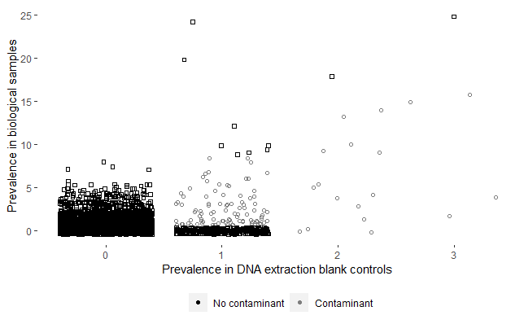

```r
# Make phyloseq objects of presence-absence of every OTU in DNA extraction blank controls versus in biological samples
ps.pa <- transform_sample_counts(physeq_excl, function(abund) 1*(abund>0))
ps.pa.neg <- prune_samples(sample_data(ps.pa)$Sample_or_Control == "False Sample", ps.pa)
ps.pa.pos <- prune_samples(sample_data(ps.pa)$Sample_or_Control == "True Sample", ps.pa)
# Make data.frame of prevalence in positive and negative samples
df.pa <- data.frame(pa.pos=taxa_sums(ps.pa.pos), pa.neg=taxa_sums(ps.pa.neg),
                      contaminant=contamdf.prev05$contaminant)
# Visualisation
ggplot(data=df.pa, aes(x=pa.neg, y=pa.pos, color = contaminant, shape = contaminant)) +
  geom_jitter() +
  scale_shape_manual(values=c(22,21)) +
  xlab("Prevalence in DNA extraction blank controls") +
  ylab("Prevalence in biological samples") +
  scale_color_manual(values= c("black", "gray50"), name = "", labels = c("No contaminant", "Contaminant")) +
  theme(panel.background = element_rect(fill = "white", linetype = "solid", colour = "white"), legend.position="bottom") +
  guides(shape = FALSE)
```

### Define putative non-contaminant OTUs using the IsNotContaminant function of the decontam package (prevalence-based)

```r
nocontamdf.prev05 <- isNotContaminant(physeq_excl, method="prevalence", neg="is.neg", threshold = 0.5)
table(nocontamdf.prev05)
```

```
nocontamdf.prev05
FALSE  TRUE
 4224   563
```

```r
which(nocontamdf.prev05)
```

```
  [1]    1    2    3    4    5   10   11   13   16   18   19   20   21   23
 [15]   24   25   32   38   44   45   46   47   49   50   52   53   57   58
 [29]   71   72   75   81   85   91   94   95  105  107  111  115  121  125
 [43]  130  131  138  140  141  142  143  144  146  147  151  154  157  160
 [57]  161  164  167  168  169  170  174  176  177  178  179  181  185  188
 [71]  190  191  193  194  196  198  199  200  201  202  203  204  205  208
 [85]  210  212  214  215  216  218  219  220  221  223  224  225  226  227
 [99]  228  229  230  231  232  233  234  235  236  238  241  242  243  246
[113]  247  248  250  251  252  253  255  256  257  258  259  261  262  263
[127]  265  266  267  268  270  274  275  277  278  280  281  282  283  285
[141]  286  287  288  289  290  291  294  295  296  297  298  299  300  302
[155]  303  304  305  306  307  308  311  312  315  316  320  321  323  324
[169]  325  327  328  330  331  332  333  334  336  337  338  341  342  344
[183]  345  346  350  351  352  353  355  356  357  358  360  362  364  366
[197]  367  368  371  372  375  377  378  379  380  381  383  384  386  387
```

[output cut: 26 more lines]

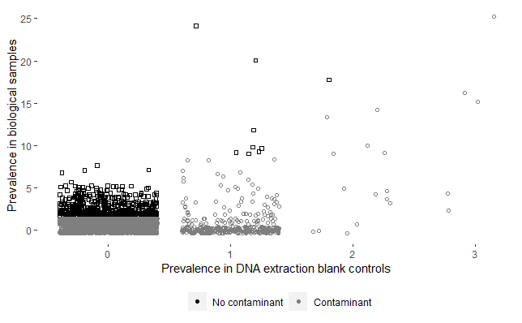

```r
# Make phyloseq objects of presence-absence of every OTU in DNA extraction blank controls versus in biological samples
ps.pa <- transform_sample_counts(physeq_excl, function(abund) 1*(abund>0))
ps.pa.neg <- prune_samples(sample_data(ps.pa)$Sample_or_Control == "False Sample", ps.pa)
ps.pa.pos <- prune_samples(sample_data(ps.pa)$Sample_or_Control == "True Sample", ps.pa)
# Make data.frame of prevalence in DNA extraction blank controls versus in biological samples
df.pa <- data.frame(pa.pos=taxa_sums(ps.pa.pos), pa.neg=taxa_sums(ps.pa.neg),
                      contaminant=!nocontamdf.prev05)
# Visualisation
ggplot(data=df.pa, aes(x=pa.neg, y=pa.pos, color = contaminant, shape = contaminant)) +
  geom_jitter() +
  scale_shape_manual(values=c(22,21)) +
  xlab("Prevalence in DNA extraction blank controls") +
  ylab("Prevalence in biological samples") +
  scale_color_manual(values= c("black", "gray50"), name = "", labels = c("No contaminant", "Contaminant")) +
  theme(panel.background = element_rect(fill = "white", linetype = "solid", colour = "white"), legend.position="bottom") +
  guides(shape = FALSE)
```

# Microbial community analyses: taxonomic identification

## Create phyloseq object “physeq_decontam” from csv file - decontaminated dataset - all samples and DNA extraction blank controls - only putative non-contaminant OTUs (IsNotContaminant function) remained

```r
# Create decontaminated otu-table
nocontam_otu <- otu_data[which(nocontamdf.prev05),]
# Taxonomy table
tax_df_decontam <- nocontam_otu %>% dplyr::select(OTU:genus)
rownames(tax_df_decontam) <- tax_df_decontam$OTU
```

```
Setting row names on a tibble is deprecated.
```

```r
# Create OTU table with all samples
otu_df_decontam <- nocontam_otu %>% dplyr::select(RT1:VAG5)
# Remove the sampling controls
otu_df_decontam <- otu_df_decontam %>% dplyr::select(-c(CTR1,CTR2,CTR3))
# Name the rows with the names of the OTUs
rownames(otu_df_decontam) <- tax_df_decontam$OTU
```

```
Setting row names on a tibble is deprecated.
```

```r
tax_df_decontam <- tax_df_decontam %>% dplyr::select(-c(OTU,Size))
physeq_decontam <- phyloseq(otu_table(otu_df_decontam, taxa_are_rows = TRUE),
                   tax_table(as.matrix(tax_df_decontam)))
physeq_decontam
```

```
phyloseq-class experiment-level object
otu_table()   OTU Table:         [ 563 taxa and 28 samples ]
tax_table()   Taxonomy Table:    [ 563 taxa by 6 taxonomic ranks ]
```

```r
colnames(tax_table(physeq_decontam)) <- c("Kingdom", "Phylum", "Class", "Order", "Family", "Genus")
rownames(metadata) <- metadata$Sample # make sure rownames are matching with physeq
sample_data(physeq_decontam) <- sample_data(metadata) # add metadata
summarize_phyloseq(physeq_decontam)
```

```
Compositional = NO2
1] Min. number of reads = 22] Max. number of reads = 891043] Total number of reads = 3326184] Average number of reads = 11879.21428571435] Median number of reads = 3677] Sparsity = 0.8992641461557986] Any OTU sum to 1 or less? NO8] Number of singletons = 09] Percent of OTUs that are singletons
        (i.e. exactly one read detected across all samples)010] Number of sample variables are: 6SampleAnimalLocationUT_or_VAGSample_or_Controlmerge_factor2
```

```
[[1]]
[1] "1] Min. number of reads = 2"

[[2]]
[1] "2] Max. number of reads = 89104"

[[3]]
[1] "3] Total number of reads = 332618"

[[4]]
[1] "4] Average number of reads = 11879.2142857143"

[[5]]
[1] "5] Median number of reads = 367"

[[6]]
[1] "7] Sparsity = 0.899264146155798"

[[7]]
[1] "6] Any OTU sum to 1 or less? NO"

[[8]]
[1] "8] Number of singletons = 0"

[[9]]
[1] "9] Percent of OTUs that are singletons \n        (i.e. exactly one read detected across all samples)0"

[[10]]
[1] "10] Number of sample variables are: 6"

[[11]]
[1] "Sample"            "Animal"            "Location"
[4] "UT_or_VAG"         "Sample_or_Control" "merge_factor"
```

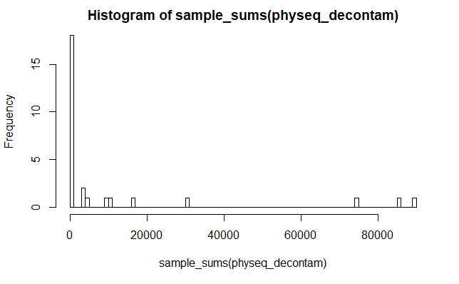

```r
# Check library sizes
hist(sample_sums(physeq_decontam), breaks = 100)
```

```r
print(sample_sums(physeq_decontam))
```

```
   RT1    RB1    LT1    LB1   VAG1 BLANK1 BLANK2    RT2    RB2    LT2    LB2
    93    356     31    378   3807      2    275    149    308  85249  89104
  VAG2    RT3    RB3    LT3    LB3   VAG3 BLANK3    RT4    RB4    LT4    LB4
  4413    284    106  74402    900   9300  10944    105    482    197    771
  VAG4    RT5    RB5    LT5    LB5   VAG5
 30066    163    276     49   3763  16645
```

```r
### number of OTUs per sample
numberotu_df_decontam <- otu_table(physeq_decontam)
colSums(numberotu_df_decontam != 0)
```

```
   RT1    RB1    LT1    LB1   VAG1 BLANK1 BLANK2    RT2    RB2    LT2    LB2
    26     18     18     14     83      2      1      8      8    125    167
  VAG2    RT3    RB3    LT3    LB3   VAG3 BLANK3    RT4    RB4    LT4    LB4
    45     22     13    146     14    203      7     11     18     17     12
  VAG4    RT5    RB5    LT5    LB5   VAG5
   244     13      9      9    158    177
```

## Decontaminated dataset - OTU level - uterine and vaginal samples - only putative non-contaminant OTUs (IsNotContaminant function) remained

### Create phyloseq object “physeq_decontam_repro” from csv file - decontaminated dataset - only samples (uterine and vaginal)

Exclude DNA extraction blank controls (for graphs)

```r
# Taxonomy table
tax_df_decontam <-nocontam_otu %>% dplyr::select(OTU:genus)
rownames(tax_df_decontam) <- tax_df_decontam$OTU
```

```
Setting row names on a tibble is deprecated.
```

```r
# Create OTU table with all samples
otu_df_decontam_repro <- nocontam_otu %>% dplyr::select(RT1:VAG5)
# Remove the control samples
otu_df_decontam_repro <- otu_df_decontam_repro %>% dplyr::select(-c(CTR1, CTR2, CTR3,BLANK1,BLANK2,BLANK3))
# Name the rows with the names of the OTUs
rownames(otu_df_decontam_repro) <- tax_df_decontam$OTU
```

```
Setting row names on a tibble is deprecated.
```

```r
tax_df_decontam <- tax_df_decontam %>% dplyr::select(-c(OTU,Size))
physeq_decontam_repro <- phyloseq(otu_table(otu_df_decontam_repro, taxa_are_rows = TRUE),
                   tax_table(as.matrix(tax_df_decontam)))
physeq_decontam_repro
```

```
phyloseq-class experiment-level object
otu_table()   OTU Table:         [ 563 taxa and 25 samples ]
tax_table()   Taxonomy Table:    [ 563 taxa by 6 taxonomic ranks ]
```

```r
colnames(tax_table(physeq_decontam_repro)) <- c("Kingdom", "Phylum", "Class", "Order", "Family", "Genus")
rownames(metadata) <- metadata$Sample # make sure rownames are matching with physeq
sample_data(physeq_decontam_repro) <- sample_data(metadata) # add metadata
summarize_phyloseq(physeq_decontam_repro)
```

```
Compositional = NO2
1] Min. number of reads = 312] Max. number of reads = 891043] Total number of reads = 3213974] Average number of reads = 12855.885] Median number of reads = 3787] Sparsity = 0.8878863232682066] Any OTU sum to 1 or less? NO8] Number of singletons = 09] Percent of OTUs that are singletons
        (i.e. exactly one read detected across all samples)010] Number of sample variables are: 6SampleAnimalLocationUT_or_VAGSample_or_Controlmerge_factor2
```

```
[[1]]
[1] "1] Min. number of reads = 31"

[[2]]
[1] "2] Max. number of reads = 89104"

[[3]]
[1] "3] Total number of reads = 321397"

[[4]]
[1] "4] Average number of reads = 12855.88"

[[5]]
[1] "5] Median number of reads = 378"

[[6]]
[1] "7] Sparsity = 0.887886323268206"

[[7]]
[1] "6] Any OTU sum to 1 or less? NO"

[[8]]
[1] "8] Number of singletons = 0"

[[9]]
[1] "9] Percent of OTUs that are singletons \n        (i.e. exactly one read detected across all samples)0"

[[10]]
[1] "10] Number of sample variables are: 6"

[[11]]
[1] "Sample"            "Animal"            "Location"
[4] "UT_or_VAG"         "Sample_or_Control" "merge_factor"
```

### Visualisation

only samples (uterine and vaginal) - decontaminated dataset - family level (HEX colors)

```r
# Relative abundance
relabphyseq_decontam_repro <- transform_sample_counts(physeq_decontam_repro, function(x) x/sum(x))
# Select 25 top OTUs based on relative abunance
TopNOTUs.relab.decontam_repro <- names(sort(taxa_sums(relabphyseq_decontam_repro), TRUE)[1:25])
physeqobj25.relab_decontam_repro  <- prune_taxa(TopNOTUs.relab.decontam_repro, relabphyseq_decontam_repro)
# Generate a barplot
phyplot.rel.decontam_repro <- plot_bar(physeqobj25.relab_decontam_repro, x ="Sample", fill="Family")
```

```
The sample variables:
Sample
 have been renamed to:
sample_Sample
to avoid conflicts with special phyloseq plot attribute names.
```

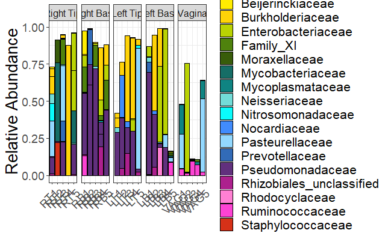

```r
phyplot.rel.decontam_repro +
  facet_grid(~ Location, scales="free_x", space = "free_x") +
  ylab("Relative Abundance")+ xlab("")+
  scale_fill_manual(values= c("#FFEC00", "#FFD308", "#BAD303", "#4F820D", "#385C0A", "#166D66", "#0F8482", "#72DCD8", "#0AFBFB", "#418CFC", "#92D8FE", "#326BB7", "#61307D", "#AD208E", "#FF80D3", "#FC43D3", "#D63118"))+
  theme_bw()+
  theme(axis.text=element_text(size=14), axis.title=element_text(size=20),
        title=element_text(size=20), legend.text=element_text(size=16),
        axis.text.x = element_text(angle = 45, hjust = 1),
        strip.text = element_text(size = 12))
```

only samples (uterine and vaginal) - decontaminated dataset - family level - Heatmap

```r
GPr  = transform_sample_counts(physeq_decontam_repro, function(x) x / sum(x) )
gpt <- prune_taxa(names(sort(taxa_sums(GPr),TRUE)[1:25]),GPr)
HM <- plot_heatmap(gpt, method = "NMDS", distance = "bray", taxa.label = 'Family', trans="log10")
```

```
The sample variables:
Sample
 have been renamed to:
sample_Sample
to avoid conflicts with special phyloseq plot attribute names.
```

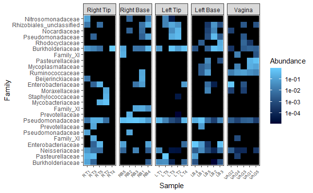

```r
HM <- HM +
  theme_bw()+
  # scale_fill_continuous(name="Relative abundance")+
  theme(axis.text.x = element_text(size=7, angle = 45, hjust = 1))+
  facet_grid(~ Location, scales="free_x", space = "free_x")
plot(HM)
```

## Decontaminated dataset - phylum level - uterine and vaginal samples

### Create Phyloseq object “physeq_phylum_scale_decontam_repro” - decontaminated dataset - pooled by phylum level - all samples

```r
# Pool at phylum level
physeq_phylum_scale_decontam_repro = tax_glom(physeq_decontam_repro, "Phylum")
# Calculate relative abundances
relabphyseq_phylum_scale_decontam_repro <- transform_sample_counts(physeq_phylum_scale_decontam_repro, function(x) 100*x/sum(x))
# Select top 5 phyla
TopNPhyla.relabphyseq_phylum_scale_decontam_repro <- names(sort(taxa_sums(relabphyseq_phylum_scale_decontam_repro), TRUE)[1:5])
tax_table(relabphyseq_phylum_scale_decontam_repro)[!taxa_names(relabphyseq_phylum_scale_decontam_repro) %in% TopNPhyla.relabphyseq_phylum_scale_decontam_repro, "Phylum"] <- "Other"
# psmelt into dataframe
df_relabphyseq_phylum_scale_decontam_repro_pruned <- psmelt(relabphyseq_phylum_scale_decontam_repro)
```

```
The sample variables:
Sample
 have been renamed to:
sample_Sample
to avoid conflicts with special phyloseq plot attribute names.
```

```r
sum_table_phyla <- df_relabphyseq_phylum_scale_decontam_repro_pruned %>% group_by(Phylum) %>% summarize(sum_abund = sum(Abundance))
names_sorted_phyla <- as.character(sum_table_phyla$Phylum)[order(sum_table_phyla$sum_abund,
                                                                  decreasing = TRUE)]
# sort families in order of abundance, put "other" last
names_sorted_phyla <- c(names_sorted_phyla[names_sorted_phyla != "Other"],
                         names_sorted_phyla[names_sorted_phyla == "Other"])
df_relabphyseq_phylum_scale_decontam_repro_pruned$Phylum <- factor(as.character(df_relabphyseq_phylum_scale_decontam_repro_pruned$Phylum),
                                       levels = names_sorted_phyla)
# Finally we merge the phyla present in "Others"
df_relabphyseq_phylum_scale_decontam_repro_pruned_remerged <- df_relabphyseq_phylum_scale_decontam_repro_pruned %>%
  group_by(Phylum, Sample) %>% summarize(sum_abund = sum(Abundance))
# Add metadata AGAIN
df_relabphyseq_phylum_scale_decontam_repro_pruned_remerged <- left_join(df_relabphyseq_phylum_scale_decontam_repro_pruned_remerged,
                                             metadata[-6],
                                                by = c("Sample" = "Sample")
                                             ) %>% distinct()
```

### Visualisation

only samples -decontaminated dataset - pooled by phylum level

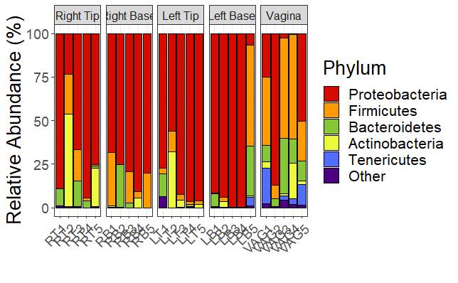

```r
# Generate a plot with the relative abundances pooled by phylum - facet by Location
phyplot.decontam.phylum_repro <- ggplot(aes(Sample, y = sum_abund,
                        fill = Phylum, color = Phylum), data = df_relabphyseq_phylum_scale_decontam_repro_pruned_remerged)+
  geom_bar(stat="identity", alpha = 1)+
  scale_color_manual(values = rep("black", 26))+
  facet_grid(~ Location, scales="free_x", space = "free_x") +
  ylab("Relative Abundance (%)")+ xlab("")+
  scale_fill_manual(values= c("#D40C00", "#FF9A00", "#87C735", "#EDFB3C", "#526EFF", "#4B0082"))+
  theme_bw()+
  theme(axis.text=element_text(size=14), axis.title=element_text(size=20),
        title=element_text(size=20), legend.text=element_text(size=16),
        axis.text.x = element_text(angle = 45, hjust = 1),
        strip.text = element_text(size = 12))
print(phyplot.decontam.phylum_repro)
```

## Decontaminated dataset - family level - uterine and vaginal samples

### Create Phyloseq object “physeq_family_scale_decontam_repro” - decontaminated dataset - pooled by family level - all samples

```r
df_relabphyseq_family_scale_decontam_repro_pruned <- psmelt(relabphyseq_family_scale_decontam_repro)
```

```
The sample variables:
Sample
 have been renamed to:
sample_Sample
to avoid conflicts with special phyloseq plot attribute names.
```

### Visualisation

only samples -decontaminated dataset - pooled by family level

```r
# Generate a plot with the relative abundances pooled by family - facet by Location
phyplot.decontam.family_repro <- ggplot(aes(Sample, y = sum_abund,
                        fill = Family, color = Family), data = df_relabphyseq_family_scale_decontam_repro_pruned_remerged)+
  geom_bar(stat="identity", alpha = 1)+
  scale_color_manual(values = rep("black", 26))+
  facet_grid(~ Location, scales="free_x", space = "free_x") +
  ylab("Relative Abundance (%)")+ xlab("")+
  scale_fill_manual(values= c("#D40C00", "#FF9A00", "#EDFB3C", "#87C735", "#526EFF", "#4B0082"))+
  theme_bw()+
  theme(axis.text=element_text(size=14), axis.title=element_text(size=20),
        title=element_text(size=20), legend.text=element_text(size=16),
        axis.text.x = element_text(angle = 45, hjust = 1),
        strip.text = element_text(size = 12))
print(phyplot.decontam.family_repro)
```

[output not shown]

## Decontaminated dataset - OTU level - only uterine samples

### Create Phyloseq object “physeq_decontamuterus” - decontaminated dataset - only uterine samples

```r
# metadata
metadata_uterus <- metadata[c(1:4, 9:12, 15:18, 22:25, 27:30),]
# Create phyloseq object from csv file
# Taxonomy table
tax_df_decontamuterus <- nocontam_otu %>% dplyr::select(OTU:genus)
rownames(tax_df_decontamuterus) <- tax_df_decontamuterus$OTU
```

```
Setting row names on a tibble is deprecated.
```

```r
# Create OTU table with only uterine samples
otu_df_decontamuterus <- nocontam_otu %>% dplyr::select(RT1:VAG5)
uterus_decontam_df <- otu_df_decontamuterus %>% dplyr::select(RT1,RT2,RT3,RT4,RT5,RB1,RB2,RB3,RB4,RB5,LT1,LT2,LT3,LT4,LT5,LB1,LB2,LB3,LB4,LB5)
# Name the rows with the names of the OTUs
rownames(uterus_decontam_df) <- tax_df_decontamuterus$OTU
```

```
Setting row names on a tibble is deprecated.
```

```r
tax_df_decontamuterus <- tax_df_decontamuterus %>% dplyr::select(-c(OTU,Size))
physeq_decontamuterus <- phyloseq(otu_table(uterus_decontam_df, taxa_are_rows = TRUE),
                   tax_table(as.matrix(tax_df_decontamuterus)))
colnames(tax_table(physeq_decontamuterus)) <- c("Kingdom", "Phylum", "Class", "Order", "Family", "Genus")
rownames(metadata) <- metadata$Sample # make sure rownames are matching with physeq
sample_data(physeq_decontamuterus) <- sample_data(metadata) # add metadata
summarize_phyloseq(physeq_decontamuterus)
```

```
Compositional = NO2
1] Min. number of reads = 312] Max. number of reads = 891043] Total number of reads = 2571664] Average number of reads = 12858.35] Median number of reads = 2967] Sparsity = 0.926642984014216] Any OTU sum to 1 or less? YES8] Number of singletons = 2099] Percent of OTUs that are singletons
        (i.e. exactly one read detected across all samples)8.1705150976909410] Number of sample variables are: 6SampleAnimalLocationUT_or_VAGSample_or_Controlmerge_factor2
```

```
[[1]]
[1] "1] Min. number of reads = 31"

[[2]]
[1] "2] Max. number of reads = 89104"

[[3]]
[1] "3] Total number of reads = 257166"

[[4]]
[1] "4] Average number of reads = 12858.3"

[[5]]
[1] "5] Median number of reads = 296"

[[6]]
[1] "7] Sparsity = 0.92664298401421"

[[7]]
[1] "6] Any OTU sum to 1 or less? YES"

[[8]]
[1] "8] Number of singletons = 209"

[[9]]
[1] "9] Percent of OTUs that are singletons \n        (i.e. exactly one read detected across all samples)8.17051509769094"

[[10]]
[1] "10] Number of sample variables are: 6"

[[11]]
[1] "Sample"            "Animal"            "Location"
[4] "UT_or_VAG"         "Sample_or_Control" "merge_factor"
```

```r
# otu table as matrix / data.frame
# Extract abundance matrix from the phyloseq object
otu_uterus_decontam = as(otu_table(physeq_decontamuterus), "matrix")
# transpose if necessary
if(taxa_are_rows(physeq_decontamuterus)){otu_uterus_decontam <- t(otu_uterus_decontam)}
# Coerce to data.frame
OTUdf_uterus_decontam = as.data.frame(otu_uterus_decontam)
```

### Visualisation

```r
# Generate a barplot - family level
phyplot.decontamuterus_family <- plot_bar(physeqobj25.relab_decontamuterus, x ="Sample", fill="Family")
```

```
The sample variables:
Sample
 have been renamed to:
sample_Sample
to avoid conflicts with special phyloseq plot attribute names.
```

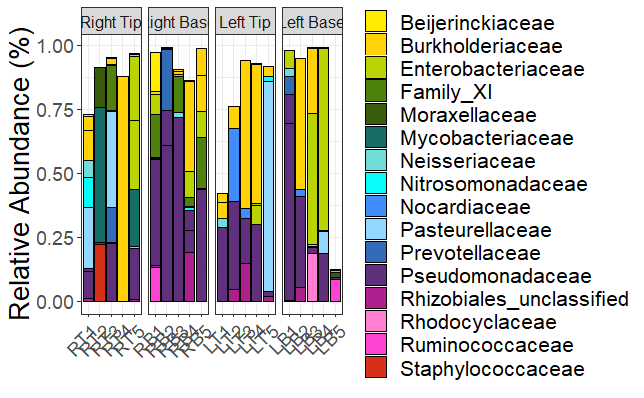

```r
phyplot.decontamuterus_family +
  facet_grid(~ Location, scales="free_x", space = "free_x") +
  ylab("Relative Abundance (%)")+ xlab("")+
  scale_fill_manual(values= c("#FFEC00", "#FFD308", "#BAD303", "#4F820D", "#385C0A", "#166D66", "#72DCD8", "#0AFBFB", "#418CFC", "#92D8FE", "#326BB7", "#61307D", "#AD208E", "#FF80D3", "#FC43D3", "#D63118"))+
  theme_bw()+
  theme(axis.text=element_text(size=14), axis.title=element_text(size=20),
        title=element_text(size=20), legend.text=element_text(size=16),
        axis.text.x = element_text(angle = 45, hjust = 1),
        strip.text = element_text(size = 12))
```

## Decontaminated dataset - OTU level - only vaginal samples

### Create Phyloseq object “physeq_decontamvag” - decontaminated dataset - only vaginal samples

```r
# metadata
metadata_vagina <- metadata[c(5,13,19,26,31),]
# Taxonomy table
tax_df_decontamvag <-nocontam_otu %>% dplyr::select(OTU:genus)
rownames(tax_df_decontamvag) <- tax_df_decontamvag$OTU
```

```
Setting row names on a tibble is deprecated.
```

```r
# Create OTU table with only uterine samples
otu_df_decontamvag <- nocontam_otu %>% dplyr::select(RT1:VAG5)
vagina_decontam_df <- otu_df_decontamvag %>% dplyr::select(VAG1, VAG2, VAG3,VAG4,VAG5)
# Name the rows with the names of the OTUs
rownames(vagina_decontam_df) <- tax_df_decontamvag$OTU
```

```
Setting row names on a tibble is deprecated.
```

```r
tax_df_decontamvag <- tax_df_decontamvag %>% dplyr::select(-c(OTU,Size))
physeq_decontamvag <- phyloseq(otu_table(vagina_decontam_df, taxa_are_rows = TRUE),
                   tax_table(as.matrix(tax_df_decontamvag)))
colnames(tax_table(physeq_decontamvag)) <- c("Kingdom", "Phylum", "Class", "Order", "Family", "Genus")
rownames(metadata) <- metadata$Sample # make sure rownames are matching with physeq
sample_data(physeq_decontamvag) <- sample_data(metadata) # add metadata
summarize_phyloseq(physeq_decontamvag)
```

```
Compositional = NO2
1] Min. number of reads = 38072] Max. number of reads = 300663] Total number of reads = 642314] Average number of reads = 12846.25] Median number of reads = 93007] Sparsity = 0.7328596802841926] Any OTU sum to 1 or less? YES8] Number of singletons = 2449] Percent of OTUs that are singletons
        (i.e. exactly one read detected across all samples)4.440497335701610] Number of sample variables are: 6SampleAnimalLocationUT_or_VAGSample_or_Controlmerge_factor2
```

```
[[1]]
[1] "1] Min. number of reads = 3807"

[[2]]
[1] "2] Max. number of reads = 30066"

[[3]]
[1] "3] Total number of reads = 64231"

[[4]]
[1] "4] Average number of reads = 12846.2"

[[5]]
[1] "5] Median number of reads = 9300"

[[6]]
[1] "7] Sparsity = 0.732859680284192"

[[7]]
[1] "6] Any OTU sum to 1 or less? YES"

[[8]]
[1] "8] Number of singletons = 244"

[[9]]
[1] "9] Percent of OTUs that are singletons \n        (i.e. exactly one read detected across all samples)4.4404973357016"

[[10]]
[1] "10] Number of sample variables are: 6"

[[11]]
[1] "Sample"            "Animal"            "Location"
[4] "UT_or_VAG"         "Sample_or_Control" "merge_factor"
```

```r
# otu table as matrix / data.frame
# Extract abundance matrix from the phyloseq object
otu_vagina_decontam = as(otu_table(physeq_decontamvag), "matrix")
# transpose if necessary
if(taxa_are_rows(physeq_decontamvag)){otu_vagina_decontam <- t(otu_vagina_decontam)}
# Coerce to data.frame
OTUdf_vagina_decontam = as.data.frame(otu_vagina_decontam)
```

### Visualisation

only vaginal samples - decontaminated dataset - family level

```r
#Relative abundance
relabphyseq_decontamvag <- transform_sample_counts(physeq_decontamvag , function(x) x/sum(x))
### Select 25 top otus based on relative abunance
TopNOTUs.relab_decontamvag <- names(sort(taxa_sums(relabphyseq_decontamvag), TRUE)[1:25])
physeqobj25.relab_decontamvag  <- prune_taxa(TopNOTUs.relab_decontamvag, relabphyseq_decontamvag)
# Generate a barplot - family level
phyplot.decontamvag_family <- plot_bar(physeqobj25.relab_decontamvag, x ="Sample", fill="Family")
```

```
The sample variables:
Sample
 have been renamed to:
sample_Sample
to avoid conflicts with special phyloseq plot attribute names.
```

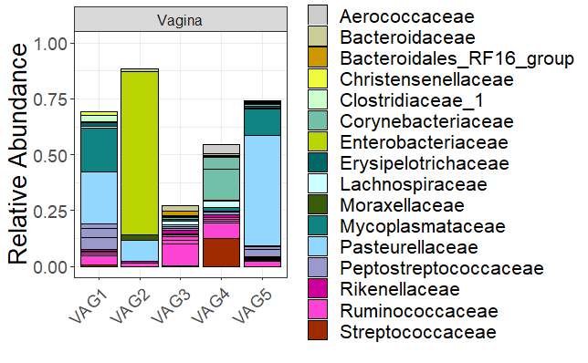

```r
phyplot.decontamvag_family +
  facet_grid(~ Location, scales="free_x", space = "free_x") +
  ylab("Relative Abundance")+ xlab("")+
  scale_y_continuous(breaks=seq(0,1,0.25), limits=c(0,1))+
  scale_fill_manual(values= c("#CCCCCC", "#CCCC99", "#CC9900", "#EDFB3C", "#CCFFCC", "#71C0A7", "#BAD303", "#006666", "#CCFFFF", "#385C0A", "#0F8482", "#92D8FE", "#9999CC", "#CC0099", "#FC43D3", "#9F2A00"))+
  theme_bw()+
  theme(axis.text=element_text(size=14), axis.title=element_text(size=20),
        title=element_text(size=20), legend.text=element_text(size=16),
        axis.text.x = element_text(angle = 45, hjust = 1),
        strip.text = element_text(size = 12))
```

# Microbial community analyses: alpha and beta diversities

## Alpha diversity

### Decontaminated dataset - uterine samples

```r
alpha_decontamuterus <- estimate_richness(physeq_decontamuterus, measures = c("Observed","Shannon", "InvSimpson"))
alpha_decontamuterus #what is the output
```

```
    Observed   Shannon InvSimpson
RT1       26 2.6446412   9.210863
RT2        8 1.2743265   2.788020
RT3       22 1.7441130   4.175606
RT4       11 0.6524039   1.299658
RT5       13 1.6388285   4.420063
RB1       18 1.7084124   4.053995
RB2        8 1.0072532   2.235144
RB3       13 1.1179211   1.864587
RB4       18 1.9981717   5.225461
RB5        9 1.5216260   3.672548
LT1       18 2.5724874   8.504425
LT2      125 1.9163022   4.590975
LT3      146 1.3489572   2.560817
LT4       17 1.3010515   2.557093
LT5        9 0.8521984   1.490379
LB1       14 1.1341068   1.998993
LB2      167 1.2538631   2.556891
LB3       14 1.2295891   2.770405
LB4       12 0.8691254   1.831376
LB5      158 4.3930197  52.653931
```

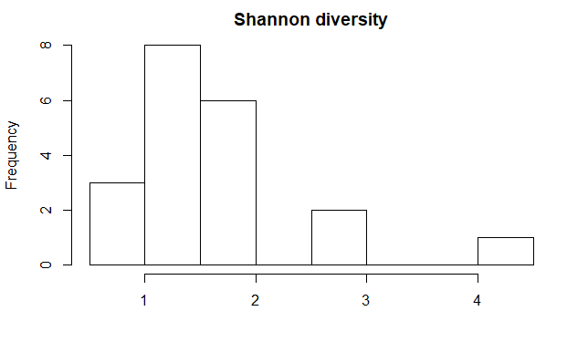

```r
hist(alpha_decontamuterus$Shannon, main="Shannon diversity", xlab="", breaks=10)
```

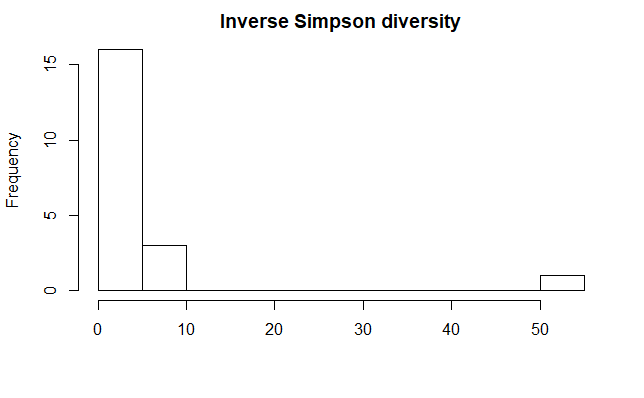

```r
hist(alpha_decontamuterus$InvSimpson, main="Inverse Simpson diversity", xlab="", breaks=10)
```

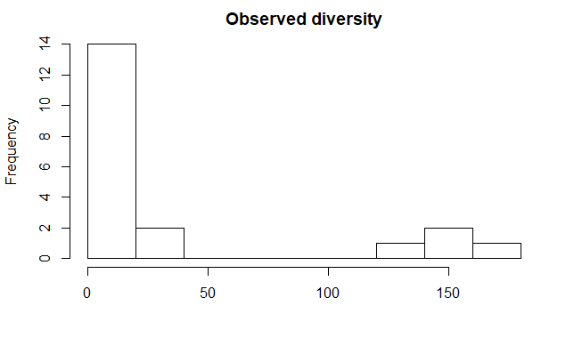

```r
hist(alpha_decontamuterus$Observed, main = "Observed diversity", xlab="", breaks=10)
```

```r
shapiro.test(alpha_decontamuterus$Shannon)
```

```
    Shapiro-Wilk normality test

data:  alpha_decontamuterus$Shannon
W = 0.80647, p-value = 0.001081
```

```r
shapiro.test(alpha_decontamuterus$InvSimpson)
```

```
    Shapiro-Wilk normality test

data:  alpha_decontamuterus$InvSimpson
W = 0.38535, p-value = 3.406e-08
```

```r
shapiro.test(alpha_decontamuterus$Observed)
```

```
    Shapiro-Wilk normality test

data:  alpha_decontamuterus$Observed
W = 0.59298, p-value = 2.493e-06
```

```r
kruskallocation_alpha_uterusdecontam <- t(sapply(alpha_decontamuterus, function(x) unlist(kruskal.test(x~sample_data(physeq_decontamuterus)$Location)[c("estimate","p.value","statistic","conf.int")])))
kruskallocation_alpha_uterusdecontam
```

```
             p.value statistic.Kruskal-Wallis chi-squared
Observed   0.4259213                            2.7853253
Shannon    0.8858919                            0.6457143
InvSimpson 0.8858919                            0.6457143
```

```r
dunn.test(alpha_decontamuterus$Shannon, sample_data(physeq_decontamuterus)$Location, method="bonferroni")
```

```
  Kruskal-Wallis rank sum test

data: x and group
Kruskal-Wallis chi-squared = 0.6457, df = 3, p-value = 0.89

                           Comparison of x by group
                                 (Bonferroni)
Col Mean-|
Row Mean |   Left Bas   Left Tip   Right Ba
---------+---------------------------------
Left Tip |  -0.694879
         |     1.0000
Right Ba |  -0.427617   0.267261
         |     1.0000     1.0000
Right Ti |  -0.694879   0.000000  -0.267261
         |     1.0000     1.0000     1.0000

alpha = 0.05
Reject Ho if p <= alpha/2
```

```r
dunn.test(alpha_decontamuterus$InvSimpson, sample_data(physeq_decontamuterus)$Location, method="bonferroni")
```

```
  Kruskal-Wallis rank sum test

data: x and group
Kruskal-Wallis chi-squared = 0.6457, df = 3, p-value = 0.89

                           Comparison of x by group
                                 (Bonferroni)
Col Mean-|
Row Mean |   Left Bas   Left Tip   Right Ba
---------+---------------------------------
Left Tip |  -0.427617
         |     1.0000
Right Ba |  -0.374165   0.053452
         |     1.0000     1.0000
Right Ti |  -0.801783  -0.374165  -0.427617
         |     1.0000     1.0000     1.0000

alpha = 0.05
Reject Ho if p <= alpha/2
```

```r
location <- c(rep(c("RT","RB","LT","LB"), each = 5))
df_alpha_decontamuterus <- cbind(alpha_decontamuterus, location)
df_alpha_decontamuterus
```

```
    Observed   Shannon InvSimpson location
RT1       26 2.6446412   9.210863       RT
RT2        8 1.2743265   2.788020       RT
RT3       22 1.7441130   4.175606       RT
RT4       11 0.6524039   1.299658       RT
RT5       13 1.6388285   4.420063       RT
RB1       18 1.7084124   4.053995       RB
RB2        8 1.0072532   2.235144       RB
RB3       13 1.1179211   1.864587       RB
RB4       18 1.9981717   5.225461       RB
RB5        9 1.5216260   3.672548       RB
LT1       18 2.5724874   8.504425       LT
LT2      125 1.9163022   4.590975       LT
LT3      146 1.3489572   2.560817       LT
LT4       17 1.3010515   2.557093       LT
LT5        9 0.8521984   1.490379       LT
LB1       14 1.1341068   1.998993       LB
LB2      167 1.2538631   2.556891       LB
LB3       14 1.2295891   2.770405       LB
LB4       12 0.8691254   1.831376       LB
LB5      158 4.3930197  52.653931       LB
```

#### Visualisation

Plot alpha diversity decontaminated dataset, uterine samples

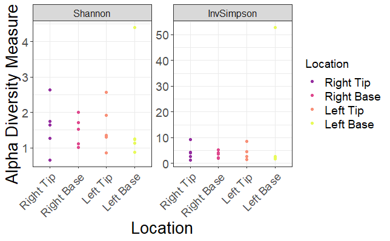

```r
plot_alpha_decontamuterus <- plot_richness(physeq_decontamuterus, x="Location", measures=c("Shannon", "InvSimpson"), color="Location") +
  theme_bw() +
  scale_color_manual(values= c("#952EA0","#DF488D", "#F89078", "#e8fa5bff"))+
  theme(axis.text=element_text(size=14), axis.title=element_text(size=20),
        title=element_text(size=14), legend.text=element_text(size=14),
        axis.text.x = element_text(angle = 45, hjust = 1),
        strip.text = element_text(size = 12))
print(plot_alpha_decontamuterus)
```

Plot alpha diversity decontaminated dataset, uterine samples, with P-values

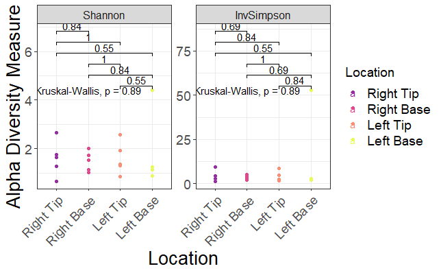

```r
my_comparisons_alpha_decontam_location <- list( c("Left Tip", "Left Base"), c("Right Base", "Left Base"), c("Right Base", "Left Tip"), c("Right Tip", "Left Base"), c("Right Tip", "Left Tip"), c("Right Tip", "Right Base") )
plot_alpha_decontamuterus_P  <- plot_richness(physeq_decontamuterus, x="Location", measures=c("Shannon", "InvSimpson"), color="Location") +
  theme_bw() +
  scale_color_manual(values= c("#952EA0","#DF488D", "#F89078", "#e8fa5bff"))+
  theme(axis.text=element_text(size=14), axis.title=element_text(size=20),
        title=element_text(size=14), legend.text=element_text(size=14),
        axis.text.x = element_text(angle = 45, hjust = 1),
        strip.text = element_text(size = 12)) +
  stat_compare_means(comparisons = my_comparisons_alpha_decontam_location)+
  stat_compare_means()
print(plot_alpha_decontamuterus_P)
```

### Decontaminated dataset - uterine samples versus vaginal samples

```r
alpha_decontamvagut <- estimate_richness(physeq_decontam_repro, measures = c("Shannon", "InvSimpson"))
alpha_decontamvagut
```

```
       Shannon InvSimpson
RT1  2.6446412   9.210863
RB1  1.7084124   4.053995
LT1  2.5724874   8.504425
LB1  1.1341068   1.998993
VAG1 3.1573639   9.544847
RT2  1.2743265   2.788020
RB2  1.0072532   2.235144
LT2  1.9163022   4.590975
LB2  1.2538631   2.556891
VAG2 1.2940760   1.828377
RT3  1.7441130   4.175606
RB3  1.1179211   1.864587
LT3  1.3489572   2.560817
LB3  1.2295891   2.770405
VAG3 4.7775761  59.095226
RT4  0.6524039   1.299658
RB4  1.9981717   5.225461
LT4  1.3010515   2.557093
LB4  0.8691254   1.831376
VAG4 4.0757045  20.810099
RT5  1.6388285   4.420063
RB5  1.5216260   3.672548
LT5  0.8521984   1.490379
LB5  4.3930197  52.653931
VAG5 2.7269489   3.818214
```

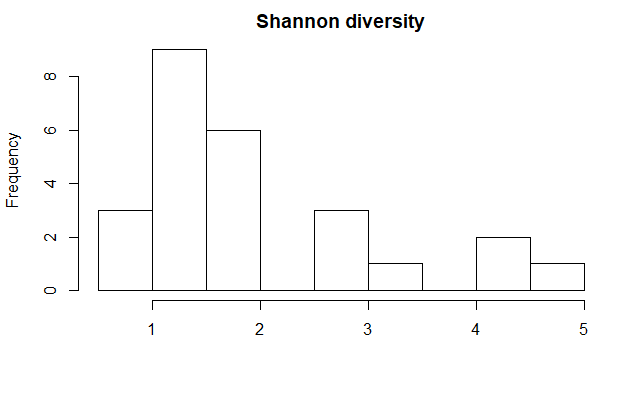

```r
hist(alpha_decontamvagut$Shannon, main="Shannon diversity", xlab="", breaks=10)
```

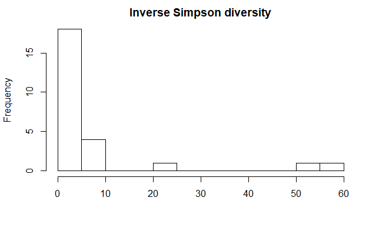

```r
hist(alpha_decontamvagut$InvSimpson, main="Inverse Simpson diversity", xlab="", breaks=10)
```

```r
shapiro.test(alpha_decontamvagut$Shannon)
```

```
    Shapiro-Wilk normality test

data:  alpha_decontamvagut$Shannon
W = 0.83938, p-value = 0.001115
```

```r
shapiro.test(alpha_decontamvagut$InvSimpson)
```

```
    Shapiro-Wilk normality test

data:  alpha_decontamvagut$InvSimpson
W = 0.49679, p-value = 3.478e-08
```

```r
wilcoxvagut_alpha_decontam <- t(sapply(alpha_decontamvagut, function(x) unlist(wilcox.test(x~sample_data(physeq_decontam_repro)$UT_or_VAG)[c("estimate","p.value","statistic","conf.int")])))
wilcoxvagut_alpha_decontam
```

```
             p.value statistic.W
Shannon    0.0121965          14
InvSimpson 0.1483155          28
```

#### Visualisation

Plot alpha diversity decontaminated dataset, uterine samples versus vaginal samples

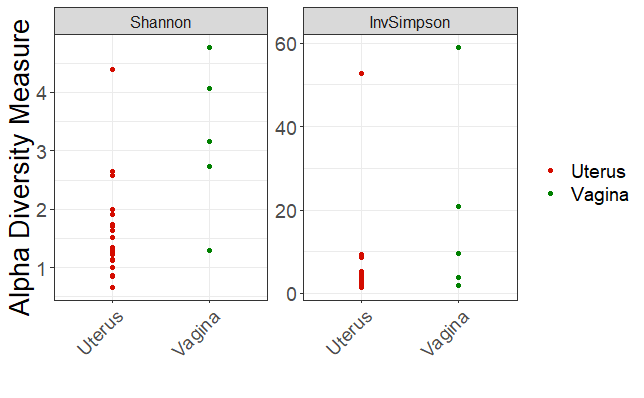

```r
plot_alpha_decontam_vagut <- plot_richness(physeq_decontam_repro, x="UT_or_VAG", measures=c("Shannon", "InvSimpson"), color="UT_or_VAG")
plot_alpha_decontam_vagut +  theme_bw() +
  scale_color_manual(values= c("#D40C00","#008000"))+
  theme(axis.text=element_text(size=14), axis.title=element_text(size=20),
        title=element_text(size=14), legend.text=element_text(size=14),
        axis.text.x = element_text(angle = 45, hjust = 1),
        strip.text = element_text(size = 12)) +
    labs(x = paste0(""),
       colour="")+
  guides(fill = guide_legend(override.aes = list(shape = 22)))
```

Plot alpha diversity decontaminated dataset, uterine samples versus vaginal samples, with P-values

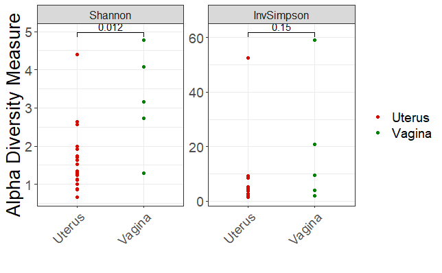

```r
my_comparisons_alpha_decontam_vagut <- list(c("Uterus", "Vagina"))
plot_alpha_decontam_vagut_P <- plot_richness(physeq_decontam_repro, x="UT_or_VAG", measures=c("Shannon", "InvSimpson"), color="UT_or_VAG") +
  theme_bw() +
  scale_color_manual(values= c("#D40C00","#008000"))+
  theme(axis.text=element_text(size=14), axis.title=element_text(size=20),
        title=element_text(size=14), legend.text=element_text(size=14),
        axis.text.x = element_text(angle = 45, hjust = 1),
        strip.text = element_text(size = 12)) +
      labs(x = paste0(""),
       colour="")+
  guides(fill = guide_legend(override.aes = list(shape = 22)))+
  stat_compare_means(comparisons = my_comparisons_alpha_decontam_vagut)
print(plot_alpha_decontam_vagut_P)
```

Plot alpha diversity decontaminated dataset, uterine samples versus vaginal samples, 5 colors, with P-values

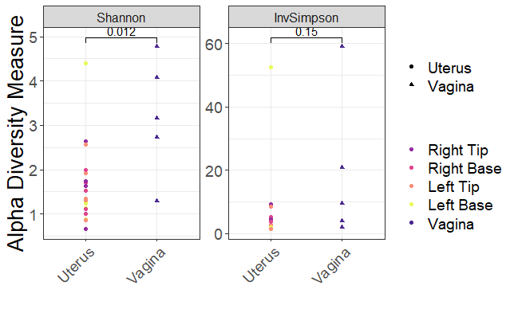

```r
plot_alpha_decontam_vagut_P5 <- plot_richness(physeq_decontam_repro, x="UT_or_VAG", measures=c("Shannon", "InvSimpson"), shape="UT_or_VAG", color = "Location") +
  theme_bw() +
  scale_shape_manual(values=c(19,17)) +
  scale_color_manual(values= c("#952EA0","#DF488D", "#F89078", "#e8fa5bff", "#4B2991"))+
  theme(axis.text=element_text(size=14), axis.title=element_text(size=20),
        title=element_text(size=14), legend.text=element_text(size=14),
        axis.text.x = element_text(angle = 45, hjust = 1),
        strip.text = element_text(size = 12)) +
      labs(x = paste0(""),
       shape="", color="")+
  stat_compare_means(comparisons = my_comparisons_alpha_decontam_vagut)
print(plot_alpha_decontam_vagut_P5)
```

## Beta diversity

### Decontaminated dataset - uterine samples

```r
# Rescale OTU table to account for library size differences

scale_reads <- function(physeq_decontamuterus, n = min(sample_sums(physeq)), round = "floor") {
  # transform counts to n
  physeq.scale_decontamuterus <- transform_sample_counts(physeq_decontamuterus,
                                          function(x) {(n * x/sum(x))}
                                          )
  # Pick the rounding functions
  if (round == "floor"){
    otu_table(physeq.scale_decontamuterus) <- floor(otu_table(physeq.scale_decontamuterus))
    } else if (round == "round"){
      otu_table(physeq.scale_decontamuterus) <- myround(otu_table(physeq.scale_decontamuterus))
      }

  # Prune taxa and return new phyloseq object
  physeq.scale_decontamuterus <- prune_taxa(taxa_sums(physeq.scale_decontamuterus) > 0, physeq.scale_decontamuterus)
  return(physeq.scale_decontamuterus)
  }

df_phy_scaled_decontamuterus <- scale_reads(physeq_decontamuterus)

# Start making the PCoA
pcoa <- ordinate(
  physeq = df_phy_scaled_decontamuterus,
  method = "PCoA",
  distance = "bray",
  correction = "lingoes",
  k=2
)

# Transform this to dataframe
pcoa.df <- data.frame(pcoa$vectors, sample_data(df_phy_scaled_decontamuterus))

# Calculate the variance explained
var <- round(pcoa$values$Eigenvalues/sum(pcoa$values$Eigenvalues)*100,1)

# Exploratory permanova to see suggested effect sizes -> Similar variances across treatments
dist.seq <- vegan::vegdist(t(otu_table(df_phy_scaled_decontamuterus)))
disper.seq <- vegan::betadisper(dist.seq, group = sample_data(df_phy_scaled_decontamuterus)$Location)
anova(disper.seq)
print(disper.seq)

# Calculate distance and save as matrix
BC.dist=vegdist(OTUdf_uterus_decontam, distance="bray")

#Run PERMANOVA on distances.
adonis(BC.dist ~ metadata_uterus$Location, data = OTUdf_uterus_decontam, permutations = 1000)

# Test homogeneity
disp.location = betadisper(BC.dist, metadata_uterus$Location)
permutest(disp.location, pairwise=TRUE, permutations=1000)
```

[output not shown]

#### Visualisation

Plot beta diversity decontaminated dataset, uterine samples

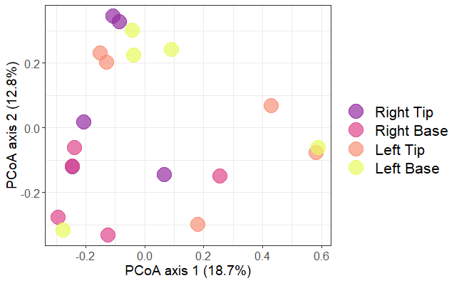

```r
plot_beta_uterusdecontam <- ggplot(data = pcoa.df, aes(x=Axis.1,
                                              y=Axis.2, color=Location))+
  geom_point(alpha=0.7, size=7)+
  theme_bw()+
  scale_color_manual(values= c("#952EA0","#DF488D", "#F89078", "#e8fa5bff"))+
  labs(x = paste0("PCoA axis 1 (",var[1], "%)"),
       y = paste0("PCoA axis 2 (",var[2], "%)"),
       colour="")+
  theme(axis.text=element_text(size=12),
        axis.title=element_text(size=14),
        title=element_text(size=20), legend.text=element_text(size=16))+
  guides(fill = guide_legend(override.aes = list(shape = 22)))
print(plot_beta_uterusdecontam)
```

### Decontaminated dataset - uterine samples versus vaginal samples

```r
metadata_utvag <- metadata[c(1:5, 9:13, 15:19, 22:31),]
#Calculate distance and save as a matrix
BC.dist=vegdist(t(otu_df_decontam_repro), distance="bray")
#Run PERMANOVA on distances.
adonis(BC.dist ~ metadata_utvag$UT_or_VAG, data = otu_df_decontam_repro, permutations = 1000)
```

```
Call:
adonis(formula = BC.dist ~ metadata_utvag$UT_or_VAG, data = otu_df_decontam_repro,      permutations = 1000)

Permutation: free
Number of permutations: 1000

Terms added sequentially (first to last)

                         Df SumsOfSqs MeanSqs F.Model      R2   Pr(>F)
metadata_utvag$UT_or_VAG  1    1.1524 1.15237  2.8712 0.11098 0.001998 **
Residuals                23    9.2311 0.40135         0.88902
Total                    24   10.3835                 1.00000
---
Signif. codes:  0 ‘***’ 0.001 ‘**’ 0.01 ‘*’ 0.05 ‘.’ 0.1 ‘ ’ 1
```

```r
# test homogeneity
disp.location = betadisper(BC.dist, metadata_utvag$UT_or_VAG)
permutest(disp.location, pairwise=TRUE, permutations=100)
```

```
Permutation test for homogeneity of multivariate dispersions
Permutation: free
Number of permutations: 100

Response: Distances
          Df   Sum Sq   Mean Sq     F N.Perm Pr(>F)
Groups     1 0.023078 0.0230784 2.614    100 0.1485
Residuals 23 0.203064 0.0088289

Pairwise comparisons:
(Observed p-value below diagonal, permuted p-value above diagonal)
        Uterus Vagina
Uterus          0.099
Vagina 0.11956
```

```r
# Rescale OTU table to account for library size differences
scale_reads <- function(physeq_decontam_repro, n = min(sample_sums(physeq_decontam_repro)), round = "floor") {
  # transform counts to n
  physeq.scale_decontam_repro <- transform_sample_counts(physeq_decontam_repro,
                                          function(x) {(n * x/sum(x))}
                                          )
  # Pick the rounding functions
  if (round == "floor"){
    otu_table(physeq.scale_decontam_repro) <- floor(otu_table(physeq.scale_decontam_repro))
    } else if (round == "round"){
      otu_table(physeq.scale_decontam_repro) <- myround(otu_table(physeq.scale_decontam_repro))
      }

  # Prune taxa and return new phyloseq object
  physeq.scale_decontam_repro <- prune_taxa(taxa_sums(physeq.scale_decontam_repro) > 0, physeq.scale_decontam_repro)
  return(physeq.scale_decontam_repro)
  }
df_phy_scaled_decontam_repro <- scale_reads(physeq_decontam_repro)
# Start making the PCoA
pcoa <- ordinate(
  physeq = df_phy_scaled_decontam_repro,
  method = "PCoA",
  distance = "bray",
  correction = "lingoes",
  k=2
)
# Transform this to dataframe
pcoa.df <- data.frame(pcoa$vectors, sample_data(df_phy_scaled_decontam_repro))
# Calculate the variance explained
var <- round(pcoa$values$Eigenvalues/sum(pcoa$values$Eigenvalues)*100,1)
# Exploratory permanova to see suggested effect sizes --> Similar variances across treatments
dist.seq <- vegan::vegdist(t(otu_table(df_phy_scaled_decontam_repro)))
disper.seq2 <- vegan::betadisper(dist.seq, group = sample_data(df_phy_scaled_decontam_repro)$UT_or_VAG)
anova(disper.seq2)
```

```
Analysis of Variance Table

Response: Distances
          Df   Sum Sq   Mean Sq F value Pr(>F)
Groups     1 0.001387 0.0013872  0.1127 0.7401
Residuals 23 0.283079 0.0123078
```

```r
print(disper.seq2)
```

```
    Homogeneity of multivariate dispersions

Call: vegan::betadisper(d = dist.seq, group =
sample_data(df_phy_scaled_decontam_repro)$UT_or_VAG)

No. of Positive Eigenvalues: 20
No. of Negative Eigenvalues: 4

Average distance to median:
Uterus Vagina
0.5902 0.5716

Eigenvalues for PCoA axes:
(Showing 8 of 24 eigenvalues)
 PCoA1  PCoA2  PCoA3  PCoA4  PCoA5  PCoA6  PCoA7  PCoA8
2.0263 1.8115 1.1169 0.9279 0.8893 0.6807 0.5324 0.4899
```

#### Visualisation

```r
# Now we can plot the beta diversity plot
pcoa.df$Location <- factor(pcoa.df$Location, levels=c("Vagina", "Right Tip", "Right Base", "Left Tip", "Left Base"))
p_beta_location_decontam <- ggplot(data = pcoa.df, aes(x=Axis.1,
                                              y=Axis.2, color=Location, shape=UT_or_VAG))+
  geom_point(alpha=0.7, size=5)+
  scale_shape_manual(values=c(19,17)) +
  scale_color_viridis(discrete=TRUE, option="plasma")+
  theme_bw()+
  labs(x = paste0("PCoA 1 (",var[1], "%)"),
       y = paste0("PCoA 2 (",var[2], "%)"),
       colour="", shape = "")+
  theme(axis.text=element_text(size=14),
        axis.title=element_text(size=20),
        title=element_text(size=20), legend.text=element_text(size=16))

print(p_beta_location_decontam)
```

[output not shown]

# Microbial community analysis: Simper

Similarity percentages to extract most influential bacteria (OTU level vs. family level)

## Decontaminated dataset - uterine samples versus vaginal samples

### phylum level

```r
physeq_vagut_phylum <- tax_glom(physeq_decontam_repro, "Phylum")
relabsphyseq_vagut_phylum <- transform_sample_counts(physeq_vagut_phylum, function(x) x/sum(x))
# Extract abundance matrix from the phyloseq object
otu_decontam_phylum = as(otu_table(relabsphyseq_vagut_phylum), "matrix")
# transpose if necessary
if(taxa_are_rows(physeq_decontam)){otu_decontam_phylum <- t(otu_decontam_phylum)}
# Coerce to data.frame
OTUdf_decontam_phylum = as.data.frame(otu_decontam_phylum)
simper(OTUdf_decontam_phylum, metadata_utvag$UT_or_VAG, permutations=200)
```

```
cumulative contributions of most influential species:

$Uterus_Vagina
  Otu0001   Otu0012
0.4506073 0.7243320
```

Test OTU0001 and OTU0012 indicated by the Simper function –> are these significantly influential phyla ?

```r
kruskal.test(OTUdf_decontam_phylum$Otu0001 ~ metadata_utvag$UT_or_VAG) #Proteobacteria*
```

```
    Kruskal-Wallis rank sum test

data:  OTUdf_decontam_phylum$Otu0001 by metadata_utvag$UT_or_VAG
Kruskal-Wallis chi-squared = 5.9815, df = 1, p-value = 0.01446
```

```r
kruskal.test(OTUdf_decontam_phylum$Otu0012 ~ metadata_utvag$UT_or_VAG) #Firmicutes
```

```
    Kruskal-Wallis rank sum test

data:  OTUdf_decontam_phylum$Otu0012 by metadata_utvag$UT_or_VAG
Kruskal-Wallis chi-squared = 7.0227, df = 1, p-value = 0.008048
```

Plot relative abundance of significantly influential phyla, decontaminated dataset, uterine samples versus vaginal samples

```r
vag_or_ut <- c(rep(c("Uterus","Uterus","Uterus","Uterus","Vagina"),5))
otu_decontam_phylum_vagut <- data.frame(OTUdf_decontam_phylum, vag_or_ut)
my_comparisons_simper_vagut <- list( c("Vagina", "Uterus"))
Proteobacteria.plot <- ggplot(data=otu_decontam_phylum_vagut, aes(x=vag_or_ut, y=Otu0001, fill=vag_or_ut))+
  geom_boxplot()+
  theme_bw()+
  scale_fill_manual(values= c("#D40C00","#008000"))+
  labs(x= "", y = "Proteobacteria \n Relative abundance")+
  theme(axis.text=element_text(size=20),
        axis.title=element_text(size=20),
        title=element_text(size=20), legend.text=element_text(size=20))+
  guides(fill = FALSE)+
  stat_compare_means(comparisons = my_comparisons_simper_vagut)
Firmicutes.plot <- ggplot(data=otu_decontam_phylum_vagut, aes(x=vag_or_ut, y=Otu0012, fill=vag_or_ut))+
  geom_boxplot()+
  theme_bw()+
  scale_fill_manual(values= c("#D40C00","#008000"))+
  labs(x= "", y = "Firmicutes \n Relative abundance")+
  theme(axis.text=element_text(size=20),
        axis.title=element_text(size=20),
        title=element_text(size=20), legend.text=element_text(size=20))+
  guides(fill = FALSE)+
  stat_compare_means(comparisons = my_comparisons_simper_vagut)
```

```
cannot compute exact p-value with ties
```

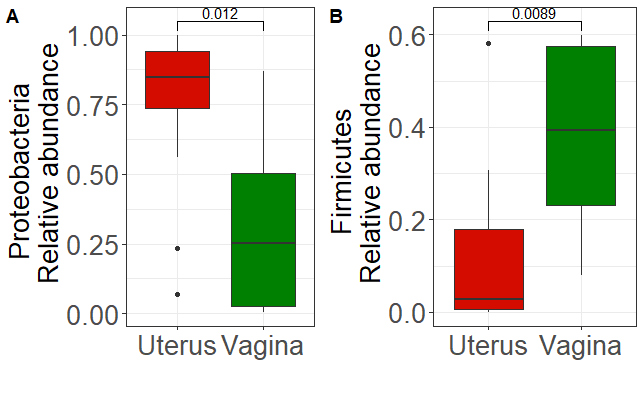

```r
plot_grid(Proteobacteria.plot, Firmicutes.plot, labels = "AUTO")
```

### family level

```r
physeq_vagut_family <- tax_glom(physeq_decontam_repro, "Family")
relabsphyseq_vagut_family <- transform_sample_counts(physeq_vagut_family , function(x) x/sum(x))
# Extract abundance matrix from the phyloseq object
otu_decontam_family = as(otu_table(relabsphyseq_vagut_family), "matrix")
# transpose if necessary
if(taxa_are_rows(physeq_decontam_repro)){otu_decontam_family <- t(otu_decontam_family)}
# Coerce to data.frame
OTUdf_decontam_family = as.data.frame(otu_decontam_family)
simper(OTUdf_decontam_family, metadata_utvag$UT_or_VAG, permutations=200)
```

```
cumulative contributions of most influential species:

$Uterus_Vagina
  Otu0002   Otu0022   Otu0001   Otu0010   Otu0017   Otu0026   Otu0073
0.1519981 0.2683539 0.3811180 0.4874216 0.5864830 0.6230572 0.6512565
  Otu0019   Otu0074   Otu0058
0.6762433 0.6990305 0.7202711
```

Test OTU0002, OTU0022, OTU0001, OTU010, OTU0017, OTU0026, OTU0073, OTU0019, OTU0074, and OTU0058 indicated by the Simper function –> are these significantly influential families ?

```r
kruskal.test(OTUdf_decontam_family$Otu0002 ~ metadata_utvag$UT_or_VAG) #Pseudomonadaceae*
```

[output not shown]

```r
kruskal.test(OTUdf_decontam_family$Otu0022 ~ metadata_utvag$UT_or_VAG) #Enterobacteriaceae
```

```
    Kruskal-Wallis rank sum test

data:  OTUdf_decontam_family$Otu0022 by metadata_utvag$UT_or_VAG
Kruskal-Wallis chi-squared = 0.54333, df = 1, p-value = 0.4611
```

```r
kruskal.test(OTUdf_decontam_family$Otu0001 ~ metadata_utvag$UT_or_VAG) #Burkholderiaceae*
```

```
    Kruskal-Wallis rank sum test

data:  OTUdf_decontam_family$Otu0001 by metadata_utvag$UT_or_VAG
Kruskal-Wallis chi-squared = 5.656, df = 1, p-value = 0.0174
```

```r
kruskal.test(OTUdf_decontam_family$Otu0010 ~ metadata_utvag$UT_or_VAG) #Pasteurellaceae*
```

```
    Kruskal-Wallis rank sum test

data:  OTUdf_decontam_family$Otu0010 by metadata_utvag$UT_or_VAG
Kruskal-Wallis chi-squared = 5.7287, df = 1, p-value = 0.01669
```

```r
kruskal.test(OTUdf_decontam_family$Otu0017 ~ metadata_utvag$UT_or_VAG) #Ruminococaceae*
```

```
    Kruskal-Wallis rank sum test

data:  OTUdf_decontam_family$Otu0017 by metadata_utvag$UT_or_VAG
Kruskal-Wallis chi-squared = 11.556, df = 1, p-value = 0.0006752
```

```r
kruskal.test(OTUdf_decontam_family$Otu0026 ~ metadata_utvag$UT_or_VAG) #Mycoplasmataceae*
```

```
    Kruskal-Wallis rank sum test

data:  OTUdf_decontam_family$Otu0026 by metadata_utvag$UT_or_VAG
Kruskal-Wallis chi-squared = 7.4079, df = 1, p-value = 0.006494
```

```r
kruskal.test(OTUdf_decontam_family$Otu0073 ~ metadata_utvag$UT_or_VAG) #Rikenellaceae*
```

```
    Kruskal-Wallis rank sum test

data:  OTUdf_decontam_family$Otu0073 by metadata_utvag$UT_or_VAG
Kruskal-Wallis chi-squared = 14.233, df = 1, p-value = 0.0001615
```

```r
kruskal.test(OTUdf_decontam_family$Otu0019 ~ metadata_utvag$UT_or_VAG)#Corynebacteriaceae*
```

```
    Kruskal-Wallis rank sum test

data:  OTUdf_decontam_family$Otu0019 by metadata_utvag$UT_or_VAG
Kruskal-Wallis chi-squared = 14.743, df = 1, p-value = 0.0001232
```

```r
kruskal.test(OTUdf_decontam_family$Otu0074 ~ metadata_utvag$UT_or_VAG) #Family_XI
```

```
    Kruskal-Wallis rank sum test

data:  OTUdf_decontam_family$Otu0074 by metadata_utvag$UT_or_VAG
Kruskal-Wallis chi-squared = 0.27413, df = 1, p-value = 0.6006
```

```r
kruskal.test(OTUdf_decontam_family$Otu0058 ~ metadata_utvag$UT_or_VAG) #Lachnospiraceae*
```

```
    Kruskal-Wallis rank sum test

data:  OTUdf_decontam_family$Otu0058 by metadata_utvag$UT_or_VAG
Kruskal-Wallis chi-squared = 16.644, df = 1, p-value = 4.51e-05
```

Plot relative abundance of significantly influential families, decontaminated dataset, uterine samples versus vaginal samples

```r
vag_or_ut <- c(rep(c("Uterus","Uterus","Uterus","Uterus","Vagina"),5))
otu_decontam_family_vagut <- data.frame(OTUdf_decontam_family, vag_or_ut)
my_comparisons_simper_vagut <- list( c("Vagina", "Uterus"))
Pseudomonadaceae.plot <- ggplot(data=otu_decontam_family_vagut, aes(x=vag_or_ut, y=Otu0002, fill=vag_or_ut))+
  geom_boxplot()+
  theme_bw()+
  scale_fill_manual(values= c("#D40C00","#008000"))+
  labs(x= "", y = "Pseudomonadaceae \n Relative abundance")+
  theme(axis.text=element_text(size=16),
        axis.title=element_text(size=16),
        title=element_text(size=16), legend.text=element_text(size=16))+
  guides(fill = FALSE)+
  stat_compare_means(comparisons = my_comparisons_simper_vagut)
Enterobacteriaceae.plot <- ggplot(data=otu_decontam_family_vagut, aes(x=vag_or_ut, y=Otu0022, fill=vag_or_ut))+
  geom_boxplot()+
  theme_bw()+
  scale_fill_manual(values= c("#D40C00","#008000"))+
  labs(x= "", y = "Enterobacteriaceae \n Relative abundance")+
  theme(axis.text=element_text(size=16),
        axis.title=element_text(size=16),
        title=element_text(size=16), legend.text=element_text(size=16))+
  guides(fill = FALSE)+
  stat_compare_means(comparisons = my_comparisons_simper_vagut)
Burkholderiaceae.plot <- ggplot(data=otu_decontam_family_vagut, aes(x=vag_or_ut, y=Otu0001, fill=vag_or_ut))+
  geom_boxplot()+
  theme_bw()+
  scale_fill_manual(values= c("#D40C00","#008000"))+
  labs(x= "", y = "Burkholderiaceae \n Relative abundance")+
  theme(axis.text=element_text(size=16),
        axis.title=element_text(size=16),
        title=element_text(size=16), legend.text=element_text(size=16))+
  guides(fill = FALSE)+
  stat_compare_means(comparisons = my_comparisons_simper_vagut)
Pasteurellaceae.plot <- ggplot(data=otu_decontam_family_vagut, aes(x=vag_or_ut, y=Otu0010, fill=vag_or_ut))+
  geom_boxplot()+
  theme_bw()+
  scale_fill_manual(values= c("#D40C00","#008000"))+
  labs(x= "", y = "Pasteurellaceae \n Relative abundance")+
  theme(axis.text=element_text(size=16),
        axis.title=element_text(size=16),
        title=element_text(size=16), legend.text=element_text(size=16))+
  guides(fill = FALSE)+
  stat_compare_means(comparisons = my_comparisons_simper_vagut)
Ruminococcaceae.plot <- ggplot(data=otu_decontam_family_vagut, aes(x=vag_or_ut, y=Otu0017, fill=vag_or_ut))+
  geom_boxplot()+
  theme_bw()+
  scale_fill_manual(values= c("#D40C00","#008000"))+
  labs(x= "", y = "Ruminococcaceae \n Relative abundance",
       colour="")+
  theme(axis.text=element_text(size=16),
        axis.title=element_text(size=16),
        title=element_text(size=16), legend.text=element_text(size=16))+
  guides(fill = FALSE)+
  stat_compare_means(comparisons = my_comparisons_simper_vagut)
Mycoplasmataceae.plot <- ggplot(data=otu_decontam_family_vagut, aes(x=vag_or_ut, y=Otu0026, fill=vag_or_ut))+
  geom_boxplot()+
  theme_bw()+
  scale_fill_manual(values= c("#D40C00","#008000"))+
  labs(x= "", y = "Mycoplasmataceae \n Relative abundance")+
  theme(axis.text=element_text(size=16),
        axis.title=element_text(size=16),
        title=element_text(size=16), legend.text=element_text(size=16))+
  guides(fill = FALSE)+
  stat_compare_means(comparisons = my_comparisons_simper_vagut)
Rikenellaceae.plot <- ggplot(data=otu_decontam_family_vagut, aes(x=vag_or_ut, y=Otu0073, fill=vag_or_ut))+
  geom_boxplot()+
  theme_bw()+
  scale_fill_manual(values= c("#D40C00","#008000"))+
  labs(x= "", y = "Rikenellaceae \n Relative abundance")+
  theme(axis.text=element_text(size=16),
        axis.title=element_text(size=16),
        title=element_text(size=16), legend.text=element_text(size=16))+
  guides(fill = FALSE)+
  stat_compare_means(comparisons = my_comparisons_simper_vagut)
Corynebacteriaceae.plot <- ggplot(data=otu_decontam_family_vagut, aes(x=vag_or_ut, y=Otu0019, fill=vag_or_ut))+
  geom_boxplot()+
  theme_bw()+
  scale_fill_manual(values= c("#D40C00","#008000"))+
  labs(x= "", y = "Corynebacteriaceae \n Relative abundance")+
  theme(axis.text=element_text(size=16),
        axis.title=element_text(size=16),
        title=element_text(size=16), legend.text=element_text(size=16))+
  guides(fill = FALSE)+
  stat_compare_means(comparisons = my_comparisons_simper_vagut)
Lachnospiraceae.plot <- ggplot(data=otu_decontam_family_vagut, aes(x=vag_or_ut, y=Otu0058, fill=vag_or_ut))+
  geom_boxplot()+
  theme_bw()+
  scale_fill_manual(values= c("#D40C00","#008000"))+
  labs(x = "" ,
       y = "Lachnospiraceae \n Relative abundance")+
  theme(axis.text=element_text(size=16),
        axis.title=element_text(size=16),
        title=element_text(size=16), legend.text=element_text(size=16))+
  guides(fill = FALSE)+
  stat_compare_means(comparisons = my_comparisons_simper_vagut)
```

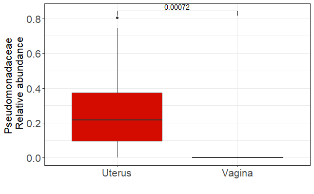

```r
plot_grid(Pseudomonadaceae.plot)
```

```
cannot compute exact p-value with ties
```

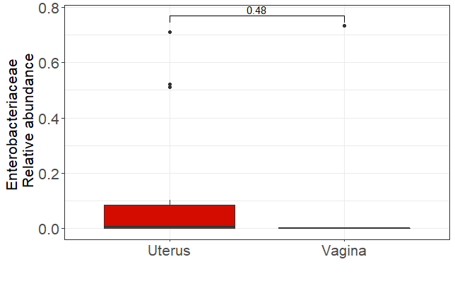

```r
plot_grid(Enterobacteriaceae.plot)
```

```
cannot compute exact p-value with ties
```

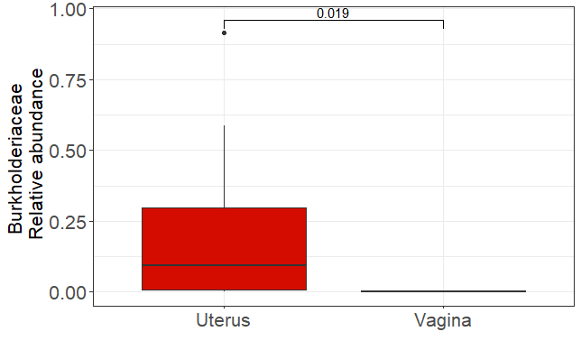

```r
plot_grid(Burkholderiaceae.plot)
```

```
cannot compute exact p-value with ties
```

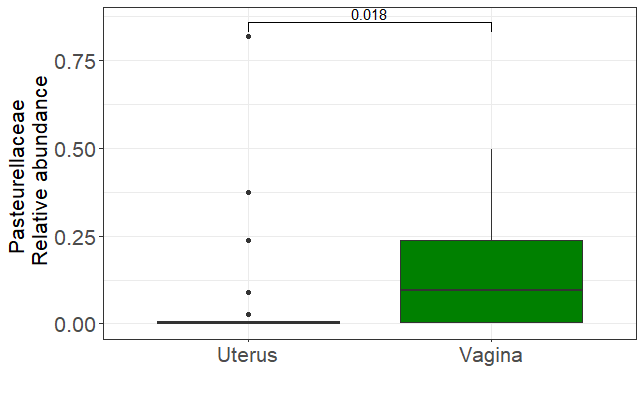

```r
plot_grid(Pasteurellaceae.plot)
```

```
cannot compute exact p-value with ties
```

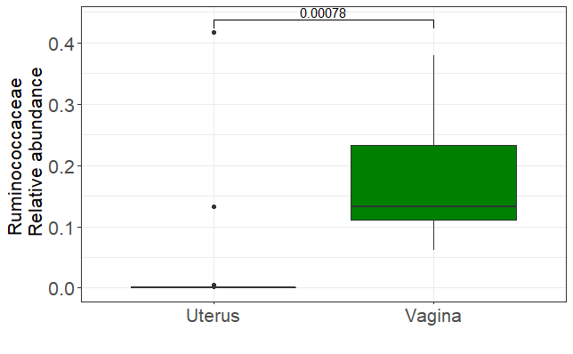

```r
plot_grid(Ruminococcaceae.plot)
```

```
cannot compute exact p-value with ties
```

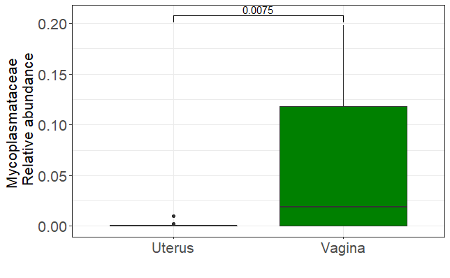

```r
plot_grid(Mycoplasmataceae.plot)
```

```
cannot compute exact p-value with ties
```

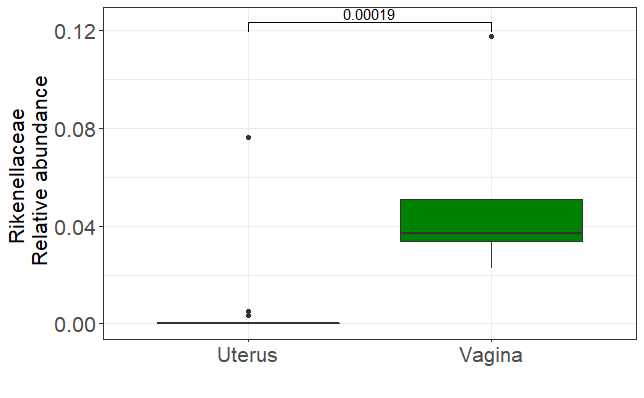

```r
plot_grid(Rikenellaceae.plot)
```

```
cannot compute exact p-value with ties
```

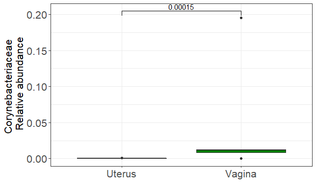

```r
plot_grid(Corynebacteriaceae.plot)
```

```
cannot compute exact p-value with ties
```

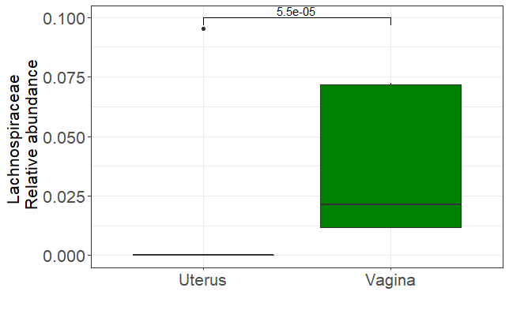

```r
plot_grid(Lachnospiraceae.plot)
```

# Microbial community analysis: Decontaminated dataset verus Original dataset

raw = original dataset decontam = decontaminated dataset

```r
raw_and_decontam_otu <- merge(otu_data, nocontam_otu, by.x="OTU", by.y = "OTU", all = TRUE)
raw_and_decontam_otu <- select(raw_and_decontam_otu, OTU, regnum.x:VAG5.x, RT1.y:VAG5.y)
raw_and_decontam_otu[is.na(raw_and_decontam_otu)] <- 0
```

```r
metadata_raw_and_decontam <- read_delim("./metadata_raw_and_decontam.csv",
    ";", escape_double = FALSE, trim_ws = TRUE)
metadata_2 <- data.frame(metadata_raw_and_decontam)
metadata_2$merge_factor <- metadata_2$Location
# Change metadata column names
metadata_2$Location <- plyr::revalue(metadata_2$Location, replace =
                                     c("RT" = "Right Tip",
                                       "RB" = "Right Base",
                                       "LT" = "Left Tip",
                                       "LB" = "Left Base",
                                       "VAG" = "Vagina",
                                       "CTR" = "Sampling Control",
                                       "BLANK" = "Extraction Blank"))
metadata_2$Location <- factor(as.character(metadata_2$Location),
                            levels = c("RT" = "Right Tip",
                                       "RB" = "Right Base",
                                       "LT" = "Left Tip",
                                       "LB" = "Left Base",
                                       "VAG" = "Vagina",
                                       "CTR" = "Sampling Control",
                                       "BLANK" = "Extraction Blank"))
```

```r
# Taxonomy table
tax_df_2 <-raw_and_decontam_otu %>% dplyr::select(OTU:genus.x)
rownames(tax_df_2) <- tax_df_2$OTU
# Create OTU table with all samples
otu_df_2 <- raw_and_decontam_otu %>% dplyr::select(RT1.x:VAG5.y)
otu_df_2 <- otu_df_2 %>% dplyr::select(-c(BLANK1.x, BLANK1.y, BLANK2.x, BLANK2.y, BLANK3.x, BLANK3.y, CTR1.x, CTR2.x, CTR3.x, CTR1.y, CTR2.y, CTR3.y))
# Name the rows with the names of the OTUs
rownames(otu_df_2) <- tax_df_2$OTU
tax_df_2 <- tax_df_2 %>% dplyr::select(-OTU)
physeq_2 <- phyloseq(otu_table(otu_df_2, taxa_are_rows = TRUE),
                   tax_table(as.matrix(tax_df_2)))
colnames(tax_table(physeq_2)) <- c("Kingdom", "Phylum", "Class", "Order", "Family", "Genus")
rownames(metadata_2) <- metadata_2$Sample # make sure rownames are matching with physeq
sample_data(physeq_2) <- sample_data(metadata_2) # add metadata
summarize_phyloseq(physeq_2)
```

[output not shown]

```
[[1]]
[1] "1] Min. number of reads = 31"

[[2]]
[1] "2] Max. number of reads = 117681"

[[3]]
[1] "3] Total number of reads = 722564"

[[4]]
[1] "4] Average number of reads = 14451.28"

[[5]]
[1] "5] Median number of reads = 777.5"

[[6]]
[1] "7] Sparsity = 0.973616043451013"

[[7]]
[1] "6] Any OTU sum to 1 or less? YES"

[[8]]
[1] "8] Number of singletons = 3498"

[[9]]
[1] "9] Percent of OTUs that are singletons \n        (i.e. exactly one read detected across all samples)45.1430958846877"

[[10]]
[1] "10] Number of sample variables are: 7"

[[11]]
[1] "Sample"               "ID"                   "Animal"
[4] "Location"             "Sample_or_Control"    "Original_or_Decontam"
[7] "merge_factor"
```

## Alpha and Beta diversity analysis

```r
ord.nmds.bray <- ordinate(physeq_2, method="NMDS", distance="bray")
```

```
Square root transformation
Wisconsin double standardization
*** No convergence -- monoMDS stopping criteria:
    20: stress ratio > sratmax
```

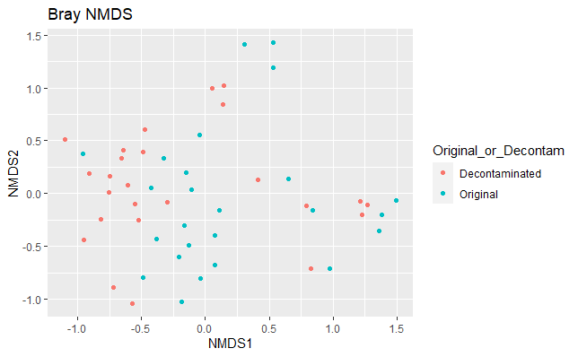

```r
plot_ordination(physeq_2, ord.nmds.bray, color="Original_or_Decontam", title="Bray NMDS")
```

```r
erich <- estimate_richness(physeq_2, measures = c("Observed","Shannon", "Simpson"))
erich #what is the output
```

```
       Observed   Shannon   Simpson
RT1.x        79 3.3202401 0.9279905
RB1.x        60 2.7418146 0.9043235
LT1.x        47 2.2666058 0.8217508
LB1.x        50 2.4516189 0.8724746
VAG1.x      205 4.0014638 0.9488215
RT2.x        26 2.3125732 0.8644149
RB2.x        23 1.6118273 0.6790118
LT2.x       736 2.5283262 0.8706520
LB2.x       711 1.7035728 0.6906026
VAG2.x      130 2.0420561 0.6026151
RT3.x        63 2.5667604 0.8781758
RB3.x        50 2.5916442 0.8851683
LT3.x       633 1.8192109 0.7033128
LB3.x        45 2.0824632 0.8159787
VAG3.x      435 5.3412006 0.9900997
RT4.x        37 2.1640084 0.8351752
RB4.x        41 2.6535662 0.8985735
LT4.x        35 2.0648716 0.7901965
LB4.x        33 1.8231644 0.7631821
VAG4.x      596 4.5730625 0.9657909
RT5.x        39 2.2801667 0.8437656
RB5.x        37 2.2703717 0.8526389
LT5.x        28 2.1698712 0.8004444
LB5.x       229 4.6000976 0.9839465
VAG5.x      369 3.1051113 0.7747360
RT1.y        26 2.6446412 0.8914325
RB1.y        18 1.7084124 0.7533298
LT1.y        18 2.5724874 0.8824142
LB1.y        14 1.1341068 0.4997480
VAG1.y       83 3.1573639 0.8952314
RT2.y         8 1.2743265 0.6413225
RB2.y         8 1.0072532 0.5526016
LT2.y       125 1.9163022 0.7821813
LB2.y       167 1.2538631 0.6089000
VAG2.y       45 1.2940760 0.4530670
RT3.y        22 1.7441130 0.7605138
RB3.y        13 1.1179211 0.4636881
LT3.y       146 1.3489572 0.6094996
LB3.y        14 1.2295891 0.6390420
VAG3.y      203 4.7775761 0.9830782
RT4.y        11 0.6524039 0.2305669
RB4.y        18 1.9981717 0.8086293
LT4.y        17 1.3010515 0.6089309
LB4.y        12 0.8691254 0.4539626
VAG4.y      244 4.0757045 0.9519464
RT5.y        13 1.6388285 0.7737589
RB5.y         9 1.5216260 0.7277095
LT5.y         9 0.8521984 0.3290296
LB5.y       158 4.3930197 0.9810081
VAG5.y      177 2.7269489 0.7380974
```

```r
kruskallocation <- t(sapply(erich, function(x) unlist(kruskal.test(x~sample_data(physeq_2)$Location)[c("estimate","p.value","statistic","conf.int")])))
kruskallocation
```

```
             p.value statistic.Kruskal-Wallis chi-squared
Observed 0.001714151                            17.268303
Shannon  0.025910813                            11.058824
Simpson  0.455180289                             3.651765
```

```r
kruskalanimal <- t(sapply(erich, function(x) unlist(kruskal.test(x~sample_data(physeq_2)$Animal)[c("estimate","p.value","statistic","conf.int")])))
kruskalanimal
```

```
           p.value statistic.Kruskal-Wallis chi-squared
Observed 0.8086686                             1.600687
Shannon  0.1679757                             6.449882
Simpson  0.1207806                             7.301647
```

```r
#Calculate distance and save as a matrix
BC.dist=vegdist(t(otu_df_2), distance="bray")
#Run PERMANOVA on distances.
adonis(BC.dist ~ metadata_2_repro$Original_or_Decontam, data = otu_df_2, permutations = 1000)
```

```
Call:
adonis(formula = BC.dist ~ metadata_2_repro$Original_or_Decontam,      data = otu_df_2, permutations = 1000)

Permutation: free
Number of permutations: 1000

Terms added sequentially (first to last)

                                      Df SumsOfSqs MeanSqs F.Model      R2
metadata_2_repro$Original_or_Decontam  1     0.529 0.52903  1.2121 0.02463
Residuals                             48    20.951 0.43647         0.97537
Total                                 49    21.480                 1.00000
                                      Pr(>F)
metadata_2_repro$Original_or_Decontam 0.2118
Residuals
Total
```

```r
disp.decontam = betadisper(BC.dist, metadata_2_repro$Original_or_Decontam)
permutest(disp.decontam, pairwise=TRUE, permutations=100)
```

```
Permutation test for homogeneity of multivariate dispersions
Permutation: free
Number of permutations: 100

Response: Distances
          Df  Sum Sq   Mean Sq      F N.Perm Pr(>F)
Groups     1 0.00070 0.0006996 0.2076    100 0.6634
Residuals 48 0.16174 0.0033697

Pairwise comparisons:
(Observed p-value below diagonal, permuted p-value above diagonal)
               Decontaminated Original
Decontaminated                  0.6634
Original              0.65069
```

```r
# Rescale OTU table to account for library size differences
scale_reads <- function(physeq, n = min(sample_sums(physeq)), round = "floor") {
  # transform counts to n
  physeq.scale_2 <- transform_sample_counts(physeq_2,
                                          function(x) {(n * x/sum(x))}
                                          )
  # Pick the rounding functions
  if (round == "floor"){
    otu_table(physeq.scale_2) <- floor(otu_table(physeq.scale_2))
    } else if (round == "round"){
      otu_table(physeq.scale_2) <- myround(otu_table(physeq.scale_2))
      }

  # Prune taxa and return new phyloseq object
  physeq.scale_2 <- prune_taxa(taxa_sums(physeq.scale_2) > 0, physeq.scale_2)
  return(physeq.scale_2)
  }
df_phy_scaled_2 <- scale_reads(physeq_2)
# Start making the PCoA
pcoa <- ordinate(
  physeq = df_phy_scaled_2,
  method = "PCoA",
  distance = "bray",
  correction = "lingoes",
  k=2
)
# Now lets transform this to dataframe
pcoa.df <- data.frame(pcoa$vectors, sample_data(df_phy_scaled_2))
# And calculate the variance explained
var <- round(pcoa$values$Eigenvalues/sum(pcoa$values$Eigenvalues)*100,1)
# Lets run an exploratory permanova to see suggested effect sizes.
# Similar variances across treatments:
dist.seq <- vegan::vegdist(t(otu_table(df_phy_scaled_2)))
disper.seq <- vegan::betadisper(dist.seq, group = sample_data(df_phy_scaled_2)$Location)
anova(disper.seq)
```

```
Analysis of Variance Table

Response: Distances
          Df  Sum Sq  Mean Sq F value Pr(>F)
Groups     4 0.07254 0.018134  1.5222 0.2118
Residuals 45 0.53607 0.011913
```

```r
print(disper.seq)
```

```
    Homogeneity of multivariate dispersions

Call: vegan::betadisper(d = dist.seq, group =
sample_data(df_phy_scaled_2)$Location)

No. of Positive Eigenvalues: 38
No. of Negative Eigenvalues: 9

Average distance to median:
 Right Tip Right Base   Left Tip  Left Base     Vagina
    0.6222     0.5062     0.5691     0.5884     0.5840

Eigenvalues for PCoA axes:
(Showing 8 of 47 eigenvalues)
 PCoA1  PCoA2  PCoA3  PCoA4  PCoA5  PCoA6  PCoA7  PCoA8
3.3038 2.9616 1.9869 1.6577 1.4729 1.2173 0.9802 0.9447
```

#### Visualisation

Plot beta diversity original versus decontaminated dataset, uterine and vaginal samples

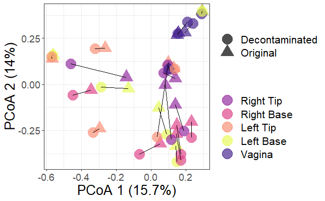

```r
plot_beta_location_original_decontam <- ggplot(data = pcoa.df, aes(x=Axis.1,
                                              y=Axis.2))+
  geom_point(alpha=0.7, size=7, aes(shape=Original_or_Decontam, color=Location))+
  geom_line(aes(group=ID))+
  scale_color_manual(values= c("#952EA0","#DF488D", "#F89078", "#e8fa5bff", "#4B2991"))+
  theme_bw()+
  labs(x = paste0("PCoA 1 (",var[1], "%)"),
       y = paste0("PCoA 2 (",var[2], "%)"),
       colour="", shape = "")+
  theme(axis.text=element_text(size=14),
        axis.title=element_text(size=20),
        title=element_text(size=20), legend.text=element_text(size=16))+
  guides(fill = guide_legend(override.aes = list(shape = 22)))
print(plot_beta_location_original_decontam)
```